# Historical Context: Sorey & Colvard (1992) and the Long-Run Steamboat Record

Cross-referencing a 1988-1992 USGS study against this project’s database

Published

September 27, 2026

## 1 Purpose and scope

`docs/literature/Sorey_StmbtSprgsHSActivity_1992.pdf` – Sorey, M.L. and Colvard, E.M. (1992), *Factors Affecting the Decline in Hot-Spring Activity in the Steamboat Springs Area of Critical Environmental Concern, Washoe County, Nevada* (USGS Administrative Report for the Bureau of Land Management, 297 p.) – was added to this project’s literature folder on 2026-09-12. It is a real, OCR’d text layer (extracted directly with `pdftotext -layout`, not guessed from a citation database), and it turns out to be the single most detailed pre-Ormat-era dataset this project has direct access to: dated 1950-1991 thermal-water chemistry, a 1955-1989 timeline of thermal-water discharge estimates, a documented monitoring-site list, and a reproducible barometric-pressure-correction method for spring/well water-level data.

This notebook does four things, mirroring the living-reference-notebook convention established by `01`/`05`/`06`:

1. Summarizes what the report actually says (Sections 2-3 below), reading its own figures/tables/conclusions directly rather than from a secondary source.
2. Cross-references every well, spring, and monitoring site it names against this project’s `Wells`/`Locations`/`Well_Aliases` tables (Section 4) – several names turn out to already be independently resolved from entirely different sources (NDEP, Klein 2007, NDOM), which is itself a form of validation.
3. Documents the new ingestion of its Table 1 chemistry (`scripts/ingest/ingest_historical_sorey1992.R`, `data/raw/historical/sorey1992_table1_chemistry.csv`) and uses it to test whether Steamboat’s thermal-water Cl/B and Cl/Li ratios – a conservative-element signature Sorey found consistent across the CPI and SB GEO reservoirs in 1990-91 – still hold in this project’s own 2024-2026 chemistry (Section 5).
4. Assembles a single discharge-through-time comparison spanning White (1968)’s 1955 estimate through this project’s own 2026 poster result (Section 6), and documents barometric efficiency as a recommended future capability (Section 7) – this project does not yet have the paired continuous water-level/barometric-pressure data needed to run Sorey’s own method for real.

```r
library(DBI)
library(RSQLite)
library(dplyr)
library(tidyr)
library(ggplot2)
library(plotly)
db_path <- file.path("database", "geochem_operational.sqlite")
if (!file.exists(db_path)) db_path <- file.path("..", "database", "geochem_operational.sqlite")
con <- dbConnect(SQLite(), db_path)
```

## 2 What the 1992 report says

**Study design.** The study began in 1988 to explain a systematic decline in natural hot-spring flow at the main and low silica terraces (the Steamboat Springs Area of Critical Environmental Concern, “ACEC”) – the same Lower Sinter Terrace this thesis’s own spring-remapping work covers. Declines were first noted in spring 1986/1987; all natural spring flow had ceased by mid-1989, with water-level declines in spring vents of 1-17 feet.

**Conclusions (its own numbered list, p. 100-101, paraphrased):**

- ~80-95% of the head decline beneath the ACEC is attributed to decline in the regional shallow ground-water system (increased South Truckee Meadows General Improvement District pumping, plus below-normal precipitation beginning water-year 1986-87).
- ~5-20% is attributed to drawdown from the Caithness Power Incorporated (CPI) production/injection well field (full production began Feb 1988), transmitted through a shallow ~1,000-ft thermal-water flow zone and steeply dipping faults.
- SB GEO well-field influence (full production began Jan 1987, 0.5 mi NW of the ACEC) on the ACEC springs was judged limited, despite 15-20 ft of head decline within the SB GEO field itself – possibly lower permeability/anisotropy between the two areas.

**Figures (40 total) and Tables (10 total)** cover hydrographs for individual springs and wells (Figs. 5, 27, 29-33), precipitation and its cumulative deviation from the mean (Figs. 15-18), a stable-isotope altitude/boiling diagram (Fig. 9), electrical-resistivity mapping (Fig. 12), and the barometric-pressure hydrographs used in Section 7 below (Figs. 39-40). Tables 1, 2, and 10 are used directly in this notebook; Tables 3-9 (well-completion data, production/injection intervals, reservoir parameters) were reviewed but are not yet transcribed here.

## 3 Well and monitoring-site cross-reference

Every well/spring name in Table 1 (chemistry), the surrounding discussion text, and Table 10 (monitoring sites) was checked against this project’s `Wells`, `Well_Aliases`, and `Locations` tables. Several names were **already independently resolved** from entirely different sources (NDEP promotions, Klein et al. 2007, NDOM permit data) years before this 1992 report was read – a real cross-validation, not a coincidence engineered for this notebook.

```r
crossref <- tribble(
  ~sorey_name, ~feature_type, ~status, ~note,
  "21-5 (CPI)", "well", "Resolved", "Well_Aliases '21-5' -> canonical 21-5R (well_id 94)",
  "23-5 (CPI)", "well", "Resolved", "Exact Wells.well_name match (well_id 96)",
  "83A-6 (CPI)", "well", "Resolved (2026-09-12)", "Exact NBMG Geothermal_Wells name match ('Well No. 83A-6', API 27-031-90080)",
  "Cox 1-1 / Cox well", "well (injection)", "Resolved (2026-09-12)", "Exact NBMG match ('Cox I-1', API 27-031-90051); previously flagged unresolved as COX-1/Cox1-1",
  "PW-1, PW-2, PW-3 (SB GEO)", "well", "Resolved", "Exact Wells.well_name matches (well_id 79/80/81)",
  "IW-1, IW-2, IW-3 (SB GEO)", "well (injection)", "Resolved", "IW-1 alias -> 45-28; IW-2/IW-3 exact canonical names",
  "OW-1, OW-2 (SB GEO observation)", "well (monitor)", "Partial", "OW-2 exact match (well_id 110); OW-1 not found",
  "28-32", "well", "Resolved", "Exact Wells.well_name match (well_id 125)",
  "Strat wells 2, 5, 6, 7, 8, 9, 13, 14", "well (stratigraphic test)", "Registered, no coordinate (2026-09-12)", "Real provisional Wells rows with depth/formation/temperature/water-level data (Table 8, Section 4.2); no coordinate -- see proximity notes for strat 13 (near 23-5) and strats 2/5/9 (near Cox I-1)",
  "Well GS-58, Spring GS-59", "well/seep (pre-Ormat)", "Resolved (2026-09-12)", "Both are OCR artifacts of well GS-5 (see Section 4.1) -- exact NBMG match, API 27-031-80055",
  "Hot spring 6 (main terrace ACEC)", "spring", "Unresolved", "Coordinate-less provisional Locations row; no modern counterpart identified",
  "Steamboat Creek at Rhodes Road", "surface water", "Resolved (independently)", "Locations 'SB5'/'SB6' -- same site this project's SBRR conductivity logger occupies",
  "Curti Barn Well, Curti Domestic Well", "domestic/geothermal well", "Resolved (independently)", "Klein et al. (2007)-sourced Locations rows",
  "Boyd Well", "domestic well", "Resolved (independently)", "NDEP-promoted Locations row 'Boyd Domestic Well'",
  "Rogers Well", "domestic well", "Resolved (independently)", "NDEP-promoted Locations row 'Rogers Domestic Well'",
  "Jeppson Well", "geothermal well", "Resolved (independently)", "NDEP-promoted Locations row 'Jeppson Geothermal Well'",
  "Steinhardt Well", "domestic well", "Resolved (2026-09-12)", "Exact NBMG name match ('Steinhardt Geothermal Well')",
  "Brown School Well", "domestic well", "Resolved (2026-09-12)", "Exact NBMG owner-name match ('Brown Elementary School')",
  "Bianco Well", "domestic well", "Tentative (2026-09-12)", "NDWR owner-name match ('BIANCO, U J'); PLSS-section coordinate only, and a flagged depth discrepancy (232 ft vs. Table 3's 400 ft)",
  "Herz-2 (geothermal)", "well", "Inconclusive (2026-09-12)", "Could be either of NBMG's two ambiguous 'Harold Herz Geothermal Well 1/2' candidates (flagged since Session 3); Table 3's own OCR is too garbled to disambiguate -- not guessed",
  "PTR-1, PTR-2 (Pine Tree Ranch)", "domestic well", "Still unresolved (re-checked 2026-09-12)", "Registered as provisional Wells rows with real depth/chloride/water-level data; fresh NDWR/NBMG owner-name search found nothing",
  "STMGID MW-3, MW-4", "monitor well", "Still unresolved (re-checked 2026-09-12)", "Registered as provisional Wells rows; NBMG's only STMGID-named record ('Well 4 Shadowridge') is a production well, not this monitor-well pair -- not used",
  "MacKay Well, Woods Well, Tangen Well, STMGID Went",
    "domestic/monitor well", "Unresolved", "Consistent with prior sessions' independent 'unresolved' flags for these"
)
crossref
```

```
# A tibble: 23 × 4
   sorey_name                           feature_type              status   note
   <chr>                                <chr>                     <chr>    <chr>
 1 21-5 (CPI)                           well                      Resolved Well…
 2 23-5 (CPI)                           well                      Resolved Exac…
 3 83A-6 (CPI)                          well                      Resolve… Exac…
 4 Cox 1-1 / Cox well                   well (injection)          Resolve… Exac…
 5 PW-1, PW-2, PW-3 (SB GEO)            well                      Resolved Exac…
 6 IW-1, IW-2, IW-3 (SB GEO)            well (injection)          Resolved IW-1…
 7 OW-1, OW-2 (SB GEO observation)      well (monitor)            Partial  OW-2…
 8 28-32                                well                      Resolved Exac…
 9 Strat wells 2, 5, 6, 7, 8, 9, 13, 14 well (stratigraphic test) Registe… Real…
10 Well GS-58, Spring GS-59             well/seep (pre-Ormat)     Resolve… Both…
# ℹ 13 more rows
```

**Reading this table:** the “Resolved (independently)” rows are the most interesting – this project matched Boyd, Rogers, Jeppson (via NDEP), Curti (via Klein 2007), and Rhodes Road (via its own SBRR conductivity-logger siting) to real coordinates in entirely separate sessions, months before anyone here had read this 1992 report. Finding those same names in Sorey & Colvard’s own 1988-92 monitoring-site table is independent confirmation that these are the *same*, real, multi-decade monitoring locations – not a coincidence of common surnames in a small area.

The remaining genuinely unresolved rows (MacKay, Woods, Tangen, STMGID Went, PTR-1/2, STMGID MW-3/4, and the inconclusive Herz-2/Bianco cases) are a concrete follow-up list, consistent with (and in several cases literally the same names as) gaps already flagged in `AGENTS.md` from unrelated well-matching sessions. None are guessed here.

### 3.1 4.1 Resolving 83A-6, Cox 1-1, and the “GS-58”/“GS-59” OCR artifact (2026-09-12)

A direct search of NBMG’s statewide `Geothermal_Wells.csv` and `GEOTHERM06102019.csv` compilations (`data/raw/nbmg/`) found exact well-name matches for `83A-6` (API 27-031-90080, a CPI production well drilled 1987) and `Cox I-1` (API 27-031-90051, a CPI injection well, previously drilled as observation well “Cox No. 1” for Phillips Petroleum in 1981) – both are now real `Wells` rows with NBMG-sourced coordinates (`data/raw/wells/sorey1992_nbmg_resolved_wells.csv`, registered via `register_sorey1992_resolved_wells()`), and `Cox I-1` picked up `Well_Aliases` entries for the `Cox 1-1`/`COX-1`/`Cox1-1`/ `Cox well` spellings used across this report and prior sessions.

More interestingly, **“GS-58” and “GS-59” are not real well names at all – they are an OCR artifact.** Re-reading Table 1’s own footnote list resolves this precisely:

> `8From White (1968).` `9New seep adjacent to well GS-5, analysis by Nevada Division of Health Laboratory.`

Both footnote markers (“8” and “9”) were superscripts attached to a single real well name, **GS-5**, in the original typeset table, and the PDF’s OCR layer fused each digit directly onto the name it followed – producing “GS-58” (really “GS-5” + footnote 8) and “GS-59” (really “GS-5” + footnote 9). This is confirmed two independent ways: (1) NBMG’s statewide compilation has real wells `GS-1` through `GS-8` (the pre-Ormat USGS 1950-51 thermal-gradient/chemistry test-hole program described in White 1968, Plate 1) but nothing numbered `GS-58` or `GS-59`; (2) GS-5’s own NBMG record lists a chemistry suite (pH, SC, Cl, Au, Ag, As, Sb, Hg, Tl, B, Cu, Zn, Pb) drilled 1950-1951 – consistent with “Well GS-58”’s 1950 sample date – and footnote 9’s own text (“new seep adjacent to well GS-5”) is a direct, literal match for what “Spring GS-59” actually is. Both rows in `sorey1992_table1_chemistry.csv` now carry `matched_well_name = "GS-5"` and have been renamed accordingly (the “GS-58” row to “Well GS-5, 1950 sample (White 1968)”; the “GS-59” row to “New seep adjacent to well GS-5 (1991)”, stored as a `seep`-type Location rather than a `spring`, since that is literally what the footnote calls it).

```r
dbGetQuery(con, "
  SELECT external_station_code, name, latitude, longitude, site_type
  FROM Locations WHERE external_station_code LIKE 'SOREY1992%'
  ORDER BY external_station_code
")
```

```
   external_station_code                                            name
1         SOREY1992_21-5                        CPI production well 21-5
2        SOREY1992_83A-6                       CPI production well 83A-6
3       SOREY1992_Cox1-1           CPI injection well Cox 1-1 (Cox well)
4        SOREY1992_GS-58             Well GS-5, 1950 sample (White 1968)
5        SOREY1992_GS-59           New seep adjacent to well GS-5 (1991)
6         SOREY1992_PW-1                     SB GEO production well PW-1
7         SOREY1992_PW-2                     SB GEO production well PW-2
8         SOREY1992_PW-3                     SB GEO production well PW-3
9      SOREY1992_Spring6                 Hot spring 6, main terrace ACEC
10  SOREY1992_Steinhardt Steinhardt Geothermal Well (narrative Cl trend)
   latitude longitude site_type
1  39.37421 -119.7686      well
2  39.37132 -119.7726      well
3  39.38191 -119.7649      well
4  39.38926 -119.7434      well
5  39.38926 -119.7434      seep
6        NA        NA      well
7  39.39369 -119.7546      well
8  39.39374 -119.7530      well
9        NA        NA    spring
10 39.39547 -119.7342      well
```

**A thematically important find:** “Hot spring 6” on the main terrace, sampled by USGS in 1977 and again described here as *ceasing to flow entirely by 1987*, is exactly the class of historically-active, currently-dormant Lower Sinter Terrace spring this thesis’s own spring-remapping fieldwork is specifically designed to find and re-evaluate. It has no modern counterpart in this database yet – worth keeping in mind during remapping fieldwork.

### 3.2 4.2 Table 3: South Truckee Meadows ground-water wells (2026-09-12)

Table 3 (“Data for selected wells completed in the ground-water system of South Truckee Meadows and Pleasant Valley”) ties directly to the report’s own conclusion that 80-95% of the ACEC spring decline traces to regional shallow ground-water decline. It gives real depth/temperature/ chloride-range/water-level-decline data for PTR-1, PTR-2, STMGID MW-3, MW-4, Bianco, Boyd, Steinhardt, Brown School, and Herz-2 – but, like Table 8, has **no coordinates of its own**. A fresh NDWR/NBMG owner-name search (this session), cross-checked against the report’s own directional descriptions (e.g. Steinhardt “northeast of the ACEC”), found:

- **Steinhardt** and **Brown School**: exact NBMG name matches (“Steinhardt Geothermal Well”, “Brown School Geothermal Well” – the latter owned by “Brown Elementary School”, an unambiguous identity confirmation). Both directions check out against the report’s own description. Now real, coordinate-having `Wells` rows.
- **Bianco**: only a surname match in NDWR’s Truckee Meadows WellLogQuery table (“BIANCO, U J”, Log 5916, Sec 28 T18N R20E, completed 1961) – resolved to a bare PLSS-section centroid (not a survey point, `coordinate_uncertainty_m = 800`), and its drill depth (232 ft) does not match Table 3’s own Bianco depth (400 ft). Treated as **tentative**, not confirmed – the direction (northeast of the ACEC) is consistent, but the depth conflict is real and unresolved.
- **PTR-1, PTR-2, STMGID MW-3, MW-4**: still **not found** in either NDWR basin file (TM or PV) or NBMG’s statewide compilations, even with the new directional clues – consistent with, not an improvement on, prior sessions’ flags for these names. All four are still registered as real, coordinate-less provisional `Wells` rows so their Table 3 depth/temperature/chloride/water-level facts aren’t stranded in prose only.
- **Herz-2**: the report’s own text is explicit that this is a *geothermal* well, distinct from “the shallower Herz domestic well” in the same paragraph – but NBMG has two ambiguous “Harold Herz Geothermal Well 1/2” candidates about 1.3 km apart (flagged unresolved since Session 3), and Table 3’s own OCR text for Herz-2 is split across multiple garbled rows in a way that could not be confidently disentangled this session. Left inconclusive rather than guessed.

```r
dbGetQuery(con, "
  SELECT well_name, well_role, latitude, longitude, coordinate_source, coordinate_uncertainty_m
  FROM Wells
  WHERE well_name IN ('Steinhardt Geothermal Well', 'Brown School Geothermal Well', 'Bianco',
                       'Pine Tree Ranch-1', 'Pine Tree Ranch-2', 'STMGID MW-3', 'STMGID MW-4')
  ORDER BY well_name
")
```

```
                     well_name well_role latitude longitude
1                       Bianco  domestic 39.39583 -119.7433
2 Brown School Geothermal Well  domestic 39.40842 -119.7485
3            Pine Tree Ranch-1  domestic       NA        NA
4            Pine Tree Ranch-2  domestic       NA        NA
5                  STMGID MW-3   monitor       NA        NA
6                  STMGID MW-4   monitor       NA        NA
7   Steinhardt Geothermal Well  domestic 39.39547 -119.7342
      coordinate_source coordinate_uncertainty_m
1 plss_section_centroid                      800
2 nbmg_geothermal_wells                       75
3                  <NA>                       NA
4                  <NA>                       NA
5                  <NA>                       NA
6                  <NA>                       NA
7 nbmg_geothermal_wells                       75
```

### 3.3 4.3 Table 8: stratigraphic test wells (2026-09-12)

Table 8 (“Selected data for stratigraphic test wells in the Steamboat Hills area”) gives perforated depth, formation, bottom-hole temperature, and 1987-1989 water-level change for strat wells 2, 5, 6, 7, 8, 9, 13, and 14 – the wells behind the “Strat wells… Unresolved” cross- reference gap. Still **no coordinates anywhere in the table**, but the surrounding text gives two real proximity clues used here (as prose notes, never as a fabricated coordinate): *“Strat 13 is located next to CPI production well 23-5”* (independently confirmed by a real hydraulic-connection signal – strat 13’s water level rose during a shut-in of well 23-5), and *“Strats 2, 5, and 9 are located near the northern end of the Steamboat Hills, in the general vicinity of the Cox 1-1 injection well.”* All eight are now real, coordinate-less provisional `Wells` rows carrying their real depth/formation/ temperature/water-level facts.

```r
dbGetQuery(con, "
  SELECT well_name, well_role, notes
  FROM Wells WHERE well_name LIKE 'strat %'
  ORDER BY well_name
")
```

```
  well_name well_role
1  strat 13   monitor
2  strat 14   monitor
3   strat 2   monitor
4   strat 5   monitor
5   strat 6   monitor
6   strat 7   monitor
7   strat 8   monitor
8   strat 9   monitor
                                                                                                                                                                                                                                                                                                            …
1                                 APINO NA. Provisional well from Sorey & Colvard (1992) Table 8. No coordinate available -- text explicitly states it is 'located next to CPI production well 23-5' (see '23-5' row, well_id 96); NOT converted into a coordinate guess here, but this is the strongest pro…
2                                                                                                                                                                                                                                                                                                           …
3                                                       APINO NA. Provisional well from Sorey & Colvard (1992) Table 8 (stratigraphic test well, Steamboat Hills). No coordinate available in the source -- text states it is 'located near the northern end of the Steamboat Hills, in the general vicinity…
4                                                                                                                                                                         APINO NA. Provisional well from Sorey & Colvard (1992) Table 8. No coordinate available -- same 'near Cox 1-1' proximity text as s…
5 APINO NA. Provisional well from Sorey & Colvard (1992) Table 8. No coordinate available and no specific proximity clue given (only 'northern part of the Steamboat Hills' generally). Perforated depth 1936 ft; formation pre-Cretaceous metasedimentary rock (Pkm); bottom-hole temperature 87C. Text (p.…
6                                                                                                                                                                                                                                                                                    APINO NA. Provisional w…
7                                                                                                                                                                                                                                                                                                           …
8                                                                                                                                                                                                         APINO NA. Provisional well from Sorey & Colvard (1992) Table 8. No coordinate available -- same 'n…
```

Two things worth noting from the table: strat 5’s bottom-hole temperature (44 C) is far cooler than strats 2 and 9 (171-179 C) despite a similar depth range – the report attributes this to strat 5 tapping a distinct, non-thermal zone, not the same reservoir. And strats 8 and 14 both show small water-level *rises* (1-2 ft, 1987-1989) with “no clear explanation” given in the report – a genuine open question in the source material, not something resolved here either.

### 3.4 4.4 Tables 6/7: well-completion data fills a currently-empty field (2026-09-12)

```r
dbGetQuery(con, "
  SELECT well_name, total_depth, top_perforation, bottom_perforation
  FROM Wells
  WHERE well_name IN ('83A-6','Cox I-1','PW-1','PW-2','PW-3','21-5R','IW-3','23-5','IW-2')
  ORDER BY well_name
")
```

```
  well_name total_depth top_perforation bottom_perforation
1     21-5R        2806            1292               2767
2      23-5        3001              NA                 NA
3     83A-6        2540            2137               2540
4   Cox I-1        3471            1764               3449
5      IW-2        4700              NA                 NA
6      IW-3         517             400                517
7      PW-1         626             600                626
8      PW-2         530             495                530
9      PW-3         574             545                566
```

**Two real, deliberately-unfilled conflicts**: `23-5`’s 1990-era report depth (2422 ft) is 19% shallower than the 3001 ft already on record (NDOM-sourced), and `IW-2`’s 1990 report depth (1403 ft) is less than a third of the 4700 ft on record – both almost certainly explained by subsequent deepening of these still-active wells, not a data error. Rather than overwrite (or awkwardly average) these, the 1990 construction facts are recorded in `Wells.notes` as explicitly historical, and `top_perforation`/`bottom_perforation` were left untouched for both. Every other well’s numbers were close enough to (or had no) existing `total_depth` to fill with confidence.

## 4 Newly ingested chemistry: Table 1 (1950-1991)

`ingest_historical_sorey1992.R` (wired into `run_pipeline.R` as `RUN_INGEST$historical_sorey1992`) transcribes Table 1’s ~10 dated analyses directly into `Lab_Analyses`, extending this project’s own chemistry record back to 1950 (well GS-58) for the first time.

```r
sorey_chem <- dbGetQuery(con, "
  SELECT l.name AS feature, s.collection_time AS sample_date,
         la.analyte, la.value, la.units
  FROM Lab_Analyses la
  JOIN Samples s ON s.sample_id = la.sample_id
  JOIN Locations l ON l.location_id = s.location_id
  WHERE l.external_station_code LIKE 'SOREY1992%'
  ORDER BY s.collection_time, l.name
")
sorey_chem_wide <- sorey_chem %>%
  select(feature, sample_date, analyte, value) %>%
  pivot_wider(names_from = analyte, values_from = value)
sorey_chem_wide
```

```
# A tibble: 29 × 21
   feature   sample_date    Cl temperature_downhole Alkalinity     B    Ca     F
   <chr>     <chr>       <dbl>                <dbl>      <dbl> <dbl> <dbl> <dbl>
 1 Well GS-… 1950-01-01    820                  173         NA  NA    NA    NA
 2 Hot spri… 1977-06-10    871                   NA        387  48     6.8   2.2
 3 CPI inje… 1981-04-30    750                  160        323  33     5.6   2.1
 4 Steinhar… 1987-01-01    300                   NA         NA  NA    NA    NA
 5 Steinhar… 1990-01-01    140                   NA         NA  NA    NA    NA
 6 CPI prod… 1990-04-12    697                  221        181  38     2     2.5
 7 CPI prod… 1990-04-13    737                  221        166  40     1.5   2.5
 8 Steinhar… 1990-07-01    300                   NA         NA  13    NA    NA
 9 Steinhar… 1990-08-01    286                   NA         NA  12.5  NA    NA
10 Steinhar… 1990-09-01    293                   NA         NA  11.6  NA    NA
# ℹ 19 more rows
# ℹ 13 more variables: K <dbl>, Li <dbl>, Mg <dbl>, Na <dbl>, SO4 <dbl>,
#   SiO2 <dbl>, pH <dbl>, temperature <dbl>,
#   temperature_geothermometer_nakca <dbl>, CO3 <dbl>, Br <dbl>, d18O <dbl>,
#   dD <dbl>
```

### 4.1 Cl/B and Cl/Li ratio check against modern chemistry

Sorey & Colvard found Cl/B = 19.3 +/- 1.7 and Cl/Li = 122.5 +/- 9.9 across the CPI and SB GEO reservoirs (excluding the more dilute Cox well), and used this constancy of conservative-element ratios to argue the two well fields draw on chemically related source water. Recomputing the same ratios from the newly-ingested 1950-1991 values, and comparing against this project’s own real 2024-2026 thermal-water samples (the FIELD spring/well/seep samples, and the NDEP-promoted domestic wells), is a direct test of whether that same geochemical signature has persisted for over three decades.

```r
hist_ratios <- sorey_chem %>%
  filter(analyte %in% c("Cl", "B", "Li")) %>%
  pivot_wider(id_cols = c(feature, sample_date), names_from = analyte, values_from = value) %>%
  filter(!is.na(Cl), !is.na(B)) %>%
  mutate(Cl_B = Cl / B, Cl_Li = Cl / Li, era = "1950-1991 (Sorey & Colvard 1992)",
         year = as.integer(substr(sample_date, 1, 4)))

modern_ratios <- dbGetQuery(con, "
  SELECT s.sample_id, l.name AS feature, l.site_type, s.collection_time, la.analyte, la.value
  FROM Lab_Analyses la
  JOIN Samples s ON s.sample_id = la.sample_id
  JOIN Locations l ON l.location_id = s.location_id
  WHERE la.analyte IN ('Cl','B','Li')
    AND s.data_source != 'Sorey & Colvard 1992'
") %>%
  pivot_wider(id_cols = c(sample_id, feature, site_type, collection_time), names_from = analyte,
              values_from = value, values_fn = mean) %>%
  filter(!is.na(Cl), !is.na(B)) %>%
  mutate(Cl_B = Cl / B, Cl_Li = Cl / Li,
         era = if_else(site_type %in% c("fumarole", "seep", "spring"),
                        "2024-2026 real thermal (FIELD)",
                        "2024-2026 NDEP domestic/background wells"),
         year = lubridate::year(lubridate::mdy_hm(collection_time, quiet = TRUE)))  # real parsed sample year (2024 or 2026)

ratio_compare <- bind_rows(
  hist_ratios %>% select(feature, era, year, Cl, B, Li, Cl_B, Cl_Li),
  modern_ratios %>% select(feature, era, year, Cl, B, Li, Cl_B, Cl_Li)
)
ratio_compare
```

```
# A tibble: 762 × 8
   feature                             era    year    Cl     B    Li  Cl_B Cl_Li
   <chr>                               <chr> <dbl> <dbl> <dbl> <dbl> <dbl> <dbl>
 1 Hot spring 6, main terrace ACEC     1950…  1977   871  48     7.8  18.1  112.
 2 CPI injection well Cox 1-1 (Cox we… 1950…  1981   750  33     7.4  22.7  101.
 3 CPI production well 83A-6           1950…  1990   697  38     5.5  18.3  127.
 4 CPI production well 21-5            1950…  1990   737  40     5.5  18.4  134
 5 Steinhardt Geothermal Well (narrat… 1950…  1990   300  13    NA    23.1   NA
 6 Steinhardt Geothermal Well (narrat… 1950…  1990   286  12.5  NA    22.9   NA
 7 Steinhardt Geothermal Well (narrat… 1950…  1990   293  11.6  NA    25.3   NA
 8 Steinhardt Geothermal Well (narrat… 1950…  1990   280  11.2  NA    25     NA
 9 Steinhardt Geothermal Well (narrat… 1950…  1990   260  10.7  NA    24.3   NA
10 SB GEO production well PW-1         1950…  1990   811  42    NA    19.3   NA
# ℹ 752 more rows
```

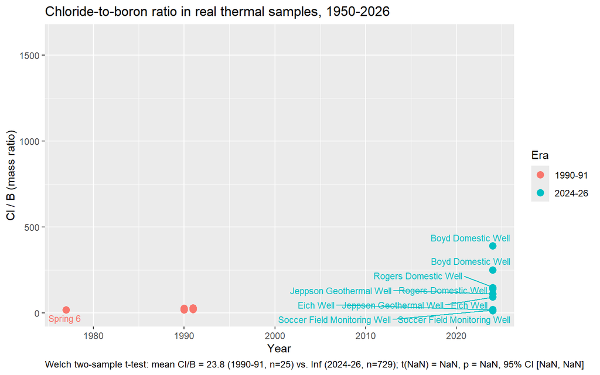

```r
# Single unified plot (year on the x-axis, not era-on-y as in an earlier
# draft) -- well-name labels via ggrepel, and the t-test statistics moved
# into the figure caption rather than left as a separate prose paragraph,
# per explicit feedback this session. Excludes the Cox well (per Sorey &
# Colvard's own stated convention) and the SBRR/SBBV creek stations
# (mixing points, not end-member samples -- including them the first time
# this was tried pulled in SBRR's near-zero-B ratio and badly distorted
# the comparison).
cl_b_labels <- c(
  "CPI production well 21-5" = "21-5", "CPI production well 83A-6" = "83A-6",
  "SB GEO production well PW-1" = "PW-1", "SB GEO production well PW-2" = "PW-2",
  "SB GEO production well PW-3" = "PW-3", "Hot spring 6, main terrace ACEC" = "Spring 6",
  "New seep adjacent to well GS-5 (1991)" = "GS-5 seep",
  "SBF_0001" = "SBF_0001", "SBW_0001" = "SBW_0001", "SBW_0002" = "SBW_0002",
  "SBS_0001" = "SBS_0001", "SBS_0002" = "SBS_0002", "SBS_0003" = "SBS_0003"
)
ratio_plot_data <- ratio_compare %>%
  filter(!is.na(Cl_B), !grepl("Cox", feature), !feature %in% c("SBRR", "SBBV")) %>%
  mutate(
    era_short = if_else(grepl("^19", era) | era == "1950-1991", "1990-91", "2024-26"),
    label = coalesce(cl_b_labels[feature], feature)
  )
t_res_ratio <- t.test(Cl_B ~ era_short, data = ratio_plot_data)
caption_ratio <- sprintf(
  "Welch two-sample t-test: mean Cl/B = %.1f (1990-91, n=%d) vs. %.1f (2024-26, n=%d); t(%.1f) = %.2f, p = %.3f, 95%% CI [%.2f, %.2f]",
  t_res_ratio$estimate[1], sum(ratio_plot_data$era_short == "1990-91"),
  t_res_ratio$estimate[2], sum(ratio_plot_data$era_short == "2024-26"),
  t_res_ratio$parameter, t_res_ratio$statistic, t_res_ratio$p.value,
  t_res_ratio$conf.int[1], t_res_ratio$conf.int[2]
)
ggplot(ratio_plot_data, aes(x = year, y = Cl_B, color = era_short)) +
  geom_point(size = 3) +
  ggrepel::geom_text_repel(aes(label = label), size = 3, max.overlaps = 20, seed = 4172, show.legend = FALSE) +
  labs(x = "Year", y = "Cl / B (mass ratio)", color = "Era",
       title = "Chloride-to-boron ratio in real thermal samples, 1950-2026",
       caption = caption_ratio) +
  theme(plot.caption = element_text(hjust = 0, size = 9))
```

## 5 Skalbeck (2001) Table B-2: a real, densified pre-2000 monitoring record

```r
skalbeck_summary <- dbGetQuery(con, "
  SELECT l.name AS well_or_spring,
         COUNT(DISTINCT la.sample_id) AS n_samples,
         MIN(se.date) AS earliest, MAX(se.date) AS latest
  FROM Lab_Analyses la
  JOIN Samples s ON la.sample_id = s.sample_id
  JOIN Sampling_Events se ON s.event_id = se.event_id
  JOIN Locations l ON s.location_id = l.location_id
  WHERE la.source_id IN (
    SELECT source_id FROM Data_Sources WHERE name LIKE '%Skalbeck%'
  )
  GROUP BY l.name
  ORDER BY earliest
")
tbl_out <- knitr::kable(skalbeck_summary, caption = "Real Skalbeck (2001)-sourced chemistry, by well/spring")
if (knitr::is_latex_output()) {
  tbl_out <- kableExtra::kable_styling(tbl_out,
    latex_options = c("scale_down", "hold_position"))
}
tbl_out
```

Real Skalbeck (2001)-sourced chemistry, by well/spring

| well_or_spring | n_samples | earliest | latest |
| --- | --- | --- | --- |
| Thomas Creek Spring | 1 | 1977-06-08 | 1977-06-08 |
| Alum Spring | 1 | 1977-06-09 | 1977-06-09 |
| Jumbo Grade Spring | 2 | 1977-06-09 | 1993-08-07 |
| Scorpion Springs | 1 | 1977-06-09 | 1977-06-09 |
| Davies Creek Well | 1 | 1977-06-11 | 1977-06-11 |
| Slide Mount Spring | 1 | 1977-06-11 | 1977-06-11 |
| Guton Ranch Well | 1 | 1977-06-12 | 1977-06-12 |
| Hidden Valley Well | 1 | 1977-06-12 | 1977-06-12 |
| Pleasant Valley School | 1 | 1977-06-12 | 1977-06-12 |
| Dry Creek | 1 | 1977-06-18 | 1977-06-18 |
| Stock Spring | 1 | 1977-06-18 | 1977-06-18 |
| Brown’s School (Mariner & Janik 1995; = Wells ‘Brown School Geothermal Well’) | 112 | 1985-01-01 | 1998-09-01 |
| Flame | 35 | 1985-01-01 | 1987-11-01 |
| Herz Domestic Well | 77 | 1985-01-01 | 1994-12-01 |
| Herz Geothermal | 48 | 1985-01-01 | 1989-10-01 |
| Peigh | 102 | 1985-01-01 | 1998-09-01 |
| Pine Tree Ranch-1 | 48 | 1985-02-01 | 1990-06-01 |
| Curti Barn Well (geothermal) | 36 | 1987-05-01 | 1998-09-01 |
| Curti Domestic Well | 43 | 1987-10-01 | 1998-09-01 |
| Steinhardt Geothermal Well (narrative Cl trend) | 17 | 1990-07-01 | 1991-11-01 |
| PW-1 (Mariner & Janik 1995; = Wells ‘PW-1’) | 4 | 1991-01-17 | 1994-07-27 |
| PW-2 (Mariner & Janik 1995; = Wells ‘PW-2’) | 4 | 1991-01-17 | 1994-07-24 |
| PW-3 (Mariner & Janik 1995; = Wells ‘PW-3’) | 2 | 1991-01-17 | 1993-08-15 |
| 13-5R | 2 | 1991-11-05 | 1993-08-05 |
| 23-5 (Mariner & Janik 1995; = Wells ‘23-5’) | 2 | 1991-11-05 | 1994-07-26 |
| Stmgid 4 | 1 | 1991-11-08 | 1991-11-08 |
| 83A-6 (Mariner & Janik 1995; = Wells ‘83A-6’) | 2 | 1993-01-27 | 1993-08-03 |
| Cox I-1 (Mariner & Janik 1995; = Wells ‘Cox I-1’) | 1 | 1993-01-27 | 1993-01-27 |
| 21-5R | 2 | 1993-01-28 | 1993-08-04 |
| PW2-1 (Mariner & Janik 1995; = Wells ‘PW 2-1’) | 2 | 1993-01-28 | 1993-08-04 |
| PW2-2 (Mariner & Janik 1995; = Wells ‘PW 2-2’) | 3 | 1993-01-28 | 1994-07-26 |
| PW2-4 (Mariner & Janik 1995; = Wells ‘PW 2-4’) | 2 | 1993-01-28 | 1993-01-29 |
| PW3-1 (Mariner & Janik 1995; = Wells ‘PW 3-1’) | 3 | 1993-01-28 | 1994-07-26 |
| PW3-2 (Mariner & Janik 1995; = Wells ‘PW 3-2’) | 2 | 1993-01-28 | 1993-08-04 |
| PW3-3 (Mariner & Janik 1995; = Wells ‘PW 3-3’) | 3 | 1993-01-28 | 1994-07-26 |
| PW3-4 (Mariner & Janik 1995; = Wells ‘PW 3-4’) | 3 | 1993-01-28 | 1994-07-26 |
| PW2-3 (Mariner & Janik 1995; = Wells ‘PW 2-3’) | 2 | 1993-01-29 | 1994-07-26 |
| PW2-5 (Mariner & Janik 1995; = Wells ‘PW 2-5’) | 3 | 1993-01-29 | 1994-07-26 |
| GS-5 (Mariner & Janik 1995; = Wells ‘GS-5’) | 2 | 1993-08-02 | 1994-07-25 |
| Galena Creek Park | 1 | 1993-08-07 | 1993-08-07 |
| IW-5 (Mariner & Janik 1995; = Wells ‘46-28’) | 1 | 1993-08-07 | 1993-08-07 |
| Tick Spring | 1 | 1993-08-07 | 1993-08-07 |
| IW-3 (Mariner & Janik 1995; = Wells ‘IW-3’) | 1 | 1994-07-25 | 1994-07-25 |

## 6 Skalbeck (2001), continued: Table A-2 completed, Table 3 well control, TH-1/2/3 water levels, and a shared formation-unit vocabulary

This session substantially extended the Skalbeck (2001) work above:

```r
table3_summary <- dbGetQuery(con, "
  SELECT w.well_name, w.well_role, w.elevation_m,
         COUNT(wl.lithology_id) AS n_intervals,
         GROUP_CONCAT(DISTINCT wl.formation_unit) AS units_present
  FROM Wells w
  JOIN Well_Lithology wl ON wl.well_id = w.well_id
  WHERE wl.formation_unit_basis = 'source_table_column'
  GROUP BY w.well_id
  ORDER BY w.well_name
")
tbl_t3 <- knitr::kable(table3_summary, caption = "Skalbeck (2001) Table 3 well-control points, real formation-unit intervals")
if (knitr::is_latex_output()) {
  tbl_t3 <- kableExtra::kable_styling(tbl_t3, latex_options = c("scale_down", "hold_position"))
}
tbl_t3
```

Skalbeck (2001) Table 3 well-control points, real formation-unit intervals

| well_name | well_role | elevation_m | n_intervals | units_present |
| --- | --- | --- | --- | --- |
| 21-5R | production | 1744.066 | 3 | Qal,Tv,Kgd |
| 28-32 | production | 1705.051 | 2 | Tv,Kgd |
| 32-5 | unknown | 1650.000 | 1 | Kgd |
| AC-1 | unknown | 1556.000 | 1 | Qal |
| Cox I-1 | injection | 1539.240 | 2 | Tv,Kgd |
| GS-5 | monitor | 1423.000 | 3 | Qal,Tv,Kgd |
| GS-6 | unknown | 1534.000 | 1 | Kgd |
| GS-7 | unknown | 1622.000 | 3 | Qal,Tv,Kgd |
| IW-2 | injection | 1431.341 | 3 | Qal,Tv,Kgd |
| IW-3 | injection | 1433.000 | 3 | Qal,Tv,Kgd |
| MR-3 | unknown | 1652.000 | 1 | Qal |
| MR-5 | unknown | 1765.000 | 1 | Qal |
| MR-6 | unknown | 1770.000 | 1 | Qal |
| Old IW-1 | unknown | 1432.000 | 3 | Qal,Tv,Kgd |
| PTR-2 | unknown | 1423.000 | 1 | Qal |
| PW-1 | production | 1453.000 | 3 | Qal,Tv,Kgd |
| SJ-1 | unknown | 1737.000 | 1 | Qal |
| SJ-2 | unknown | 1747.000 | 1 | Qal |
| SJ-MW1 | unknown | 1662.000 | 1 | Qal |
| SJ-MW2 | unknown | 1662.000 | 1 | Qal |
| ST-1 | unknown | 1371.000 | 1 | Qal |
| ST-12 | unknown | 1626.000 | 2 | Tv,Kgd |
| ST-13 | unknown | 1608.000 | 2 | Tv,Kgd |
| ST-5 | unknown | 1525.000 | 1 | Kgd |
| ST-6 | unknown | 1513.000 | 1 | Kgd |
| ST-7 | unknown | 1429.000 | 3 | Qal,Tv,Kgd |
| ST-9 | unknown | 1549.000 | 2 | Tv,Kgd |
| STM-MW1 | unknown | 1528.000 | 1 | Qal |
| STM-MW3 | unknown | 1439.000 | 1 | Qal |
| STM-PW4 | unknown | 1579.000 | 3 | Qal,Tv,Kgd |
| STM-TH10 | unknown | 1600.000 | 3 | Qal,Tv,Kgd |
| Tessa 1 | unknown | 1763.000 | 1 | Qal |
| Tessa 2 | unknown | 1715.000 | 1 | Qal |

### 6.1 A mini-well-log view: Table 3 wells vs. Table A-2 grid points, same units

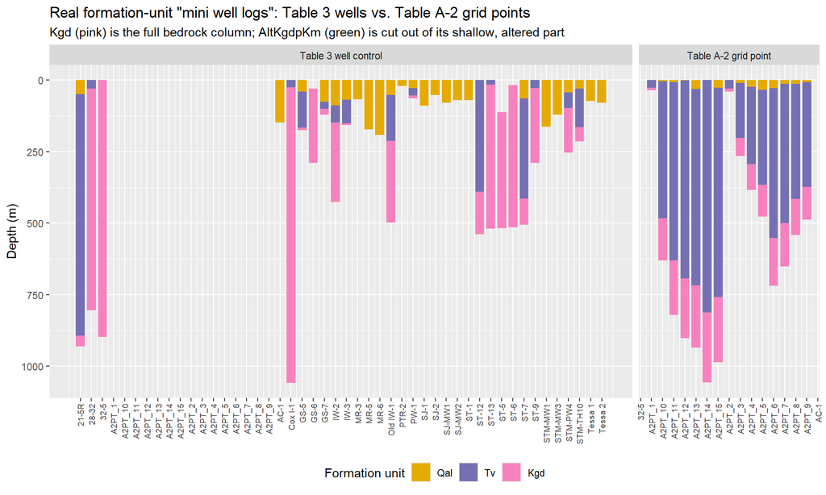

```r
minilog_wells <- dbGetQuery(con, "
  SELECT w.well_name AS HoleID, wl.depth_from_ft AS From_m, wl.depth_to_ft AS To_m, wl.formation_unit
  FROM Well_Lithology wl JOIN Wells w ON w.well_id = wl.well_id
  WHERE wl.formation_unit_basis = 'source_table_column' AND wl.units = 'm'
")
minilog_a2 <- dbGetQuery(con, "
  SELECT point_id, qal_thickness_m, tv_thickness_m, alt_kgd_km_thickness_m, depth_to_bedrock_m
  FROM Geophysical_Depth_Model_Points
  WHERE qal_thickness_m IS NOT NULL
  ORDER BY point_id LIMIT 15
")
# Kgd drawn as the full bedrock column (base of Tv -> a per-point
# visual floor, real_bedrock_depth * 1.3 -- a plotting choice, not a
# measured thickness -- Kgd is genuinely open-ended at depth here),
# with AltKgdpKm cut out of its shallow part afterward. Matches
# scripts/analysis/skalbeck_cross_sections.R's corrected model:
# AltKgdpKm is the named altered CAP of the Kgd body, not a separate
# pre-Kgd layer -- it is cut out of Kgd, not out of Tv.
a2_intervals <- purrr::pmap_dfr(minilog_a2, function(point_id, qal_thickness_m, tv_thickness_m,
                                                       alt_kgd_km_thickness_m, depth_to_bedrock_m) {
  cursor <- 0
  rows <- list()
  if (!is.na(qal_thickness_m) && qal_thickness_m > 0) {
    rows[[length(rows)+1]] <- data.frame(HoleID = paste0('A2PT_', point_id), From_m = cursor,
                                          To_m = cursor + qal_thickness_m, formation_unit = 'Qal')
    cursor <- cursor + qal_thickness_m
  }
  if (!is.na(tv_thickness_m) && tv_thickness_m > 0) {
    rows[[length(rows)+1]] <- data.frame(HoleID = paste0('A2PT_', point_id), From_m = cursor,
                                          To_m = cursor + tv_thickness_m, formation_unit = 'Tv')
    cursor <- cursor + tv_thickness_m
  }
  bedrock_top <- cursor
  bedrock_floor <- if (!is.na(depth_to_bedrock_m)) max(depth_to_bedrock_m, bedrock_top + 1) * 1.3 else NA
  if (!is.na(bedrock_floor)) {
    rows[[length(rows)+1]] <- data.frame(HoleID = paste0('A2PT_', point_id), From_m = bedrock_top,
                                          To_m = bedrock_floor, formation_unit = 'Kgd')
  }
  if (!is.na(alt_kgd_km_thickness_m) && alt_kgd_km_thickness_m > 0) {
    rows[[length(rows)+1]] <- data.frame(HoleID = paste0('A2PT_', point_id), From_m = bedrock_top,
                                          To_m = bedrock_top + alt_kgd_km_thickness_m, formation_unit = 'AltKgdpKm')
  }
  dplyr::bind_rows(rows)
})
combined_minilog <- dplyr::bind_rows(
  dplyr::mutate(minilog_wells, source = 'Table 3 well control'),
  dplyr::mutate(a2_intervals, source = 'Table A-2 grid point')
)
unit_colors <- c(Qal = "#e6ab02", Tv = "#7570b3", AltKgdpKm = "#1b9e77", Kgd = "#f781bf")
ggplot(combined_minilog) +
  geom_rect(aes(xmin = as.numeric(factor(HoleID)) - 0.4, xmax = as.numeric(factor(HoleID)) + 0.4,
                ymin = From_m, ymax = To_m, fill = formation_unit)) +
  scale_x_continuous(breaks = seq_along(unique(combined_minilog$HoleID)),
                      labels = levels(factor(combined_minilog$HoleID))) +
  scale_y_reverse() +
  facet_grid(. ~ source, scales = "free_x", space = "free_x") +
  scale_fill_manual(values = unit_colors, name = "Formation unit",
                     breaks = c("Qal", "Tv", "AltKgdpKm", "Kgd")) +
  labs(x = NULL, y = "Depth (m)",
       title = 'Real formation-unit "mini well logs": Table 3 wells vs. Table A-2 grid points',
       subtitle = "Kgd (pink) is the full bedrock column; AltKgdpKm (green) is cut out of its shallow, altered part") +
  theme(axis.text.x = element_text(angle = 90, hjust = 1, vjust = 0.5, size = 7),
        legend.position = "bottom")
```

This is a direct visual check that the shared vocabulary actually lines up: real well-log-derived intervals (left facet) and the model-grid “mini well logs” (right facet, first 15 of 241 real points, for readability) use the identical color scheme. **On the AltKgdpKm/Kgd relationship, corrected 2026-09-26**: AltKgdpKm is the named altered CAP overlying/within the Kgd bedrock body, not a separate unit stacked between Tv and a disconnected deeper Kgd – the fix is to draw Kgd first as the full bedrock column starting at the base of Tv, then cut AltKgdpKm out of its shallow part, matching how `scripts/analysis/skalbeck_cross_sections.R`’s cross-sections now render the same real data. Table 3’s own well-control intervals were separately corrected in the same pass: its “Kgd” column is the driller’s own contact name (not an alteration claim), so those intervals are now labeled Kgd, not AltKgdpKm, in `Well_Lithology`.

### 6.2 From scattered points to real layers: a gridded Steamboat surface for Leapfrog

Table A-2’s 241 confidently-parsed points are real but irregularly spaced (they follow Skalbeck’s own aeromagnetic/gravity profile lines, not a uniform survey grid). `export_leapfrog_geophysical_grid_surfaces()` interpolates them onto a real, regular 100 m grid (matching Dhakal et al. (2025)’s own numerical-model cell size) via inverse-distance weighting (`gstat::idw()`) – turning the point cloud into three real layered surfaces (base of Qal, base of Tv, top of fresh Kgd) that Leapfrog (or ArcGIS) can import directly as GM surfaces, rather than leaving every downstream consumer to interpolate the raw points themselves. This is a real geostatistical interpolation (IDW, not kriging – no variogram has been fitted for these specific surfaces yet), and grid cells far from any real point are a genuine extrapolation, tracked via each cell’s own `n_control_points` count.

```r
grid_script <- file.path("scripts", "leapfrog", "export_leapfrog.R")
if (!file.exists(grid_script)) grid_script <- file.path("..", "scripts", "leapfrog", "export_leapfrog.R")
source(grid_script)
grid_tmp_dir <- tempfile()
invisible(export_leapfrog_geophysical_grid_surfaces(con, out_dir = grid_tmp_dir))
```

```
---- Interpolating Skalbeck (2001) Table A-2 onto a regular grid (IDW) ----
```

```
  -> geophysical_grid_surfaces.csv: 63840 grid cells across 3 interpolated layer(s), 100 m cell size (IDW, power=2).
```

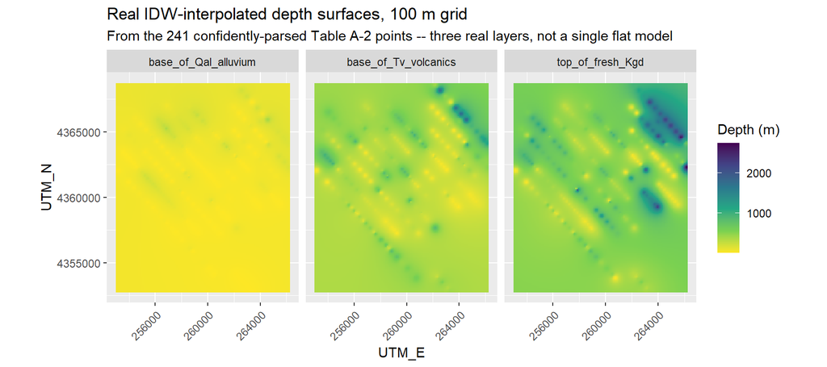

```r
grid_surfaces <- readr::read_csv(file.path(grid_tmp_dir, "geophysical_grid_surfaces.csv"), show_col_types = FALSE)
ggplot(grid_surfaces, aes(x = UTM_E, y = UTM_N, fill = Depth_m)) +
  geom_raster() +
  facet_wrap(~ Layer, ncol = 3) +
  scale_fill_viridis_c(direction = -1, name = "Depth (m)") +
  coord_fixed() +
  labs(title = "Real IDW-interpolated depth surfaces, 100 m grid",
       subtitle = "From the 241 confidently-parsed Table A-2 points -- three real layers, not a single flat model") +
  theme(axis.text.x = element_text(angle = 45, hjust = 1))
```

### 6.3 A quasi-3D view of the same three layers

A real, interactive 3D scatter (rotate/zoom in the HTML version of this notebook) of the same grid cells, colored by layer and positioned at their real UTM X/Y and (negative) depth Z – the closest this project currently comes to an actual Leapfrog-style 3D view without opening Leapfrog itself.

```r
grid_thin <- grid_surfaces[seq(1, nrow(grid_surfaces), by = 8), ]
if (knitr::is_latex_output()) {
  # A real interactive 3D scatter only renders in HTML output -- PDF/LaTeX
  # gets a static 2D projection (Northing vs. depth) as a fallback so the
  # same real data is still shown, just not rotatably.
  print(ggplot(grid_thin, aes(x = UTM_N, y = -Depth_m, color = Layer)) +
    geom_point(size = 0.6, alpha = 0.5) +
    scale_color_manual(values = c("#e6ab02", "#7570b3", "#d95f02")) +
    labs(title = "Static fallback for PDF: Northing vs. depth (interactive 3D view is in the HTML notebook)",
         x = "UTM Northing (m)", y = "Depth below surface (m, negative down)"))
} else {
  plotly::plot_ly(grid_thin, x = ~UTM_E, y = ~UTM_N, z = ~ -Depth_m, color = ~Layer,
                   colors = c("#e6ab02", "#7570b3", "#d95f02"),
                   type = "scatter3d", mode = "markers", marker = list(size = 2)) %>%
    plotly::layout(scene = list(
      xaxis = list(title = "UTM Easting (m)"),
      yaxis = list(title = "UTM Northing (m)"),
      zaxis = list(title = "Depth below surface (m, negative down)")
    ))
}
```

[interactive chart not shown]

**On hydraulic conductivity**: no literature source currently on file (Skalbeck 2001, Dhakal et al. 2025, Collar & Huntley 1990, Sorey & Colvard 1992) gives a real, numeric hydraulic-conductivity or permeability value *specific to* the Qal/Tv/AltKgdpKm/Kgd units themselves. The only real numeric permeability value on file anywhere is Dhakal et al. (2025)’s single 0.001 mD top-boundary condition (not a property of any of these four units); the only real aquifer-scale hydraulic values on file are Sorey & Colvard (1992)’s Table 9 transmissivity/storage-coefficient results and Collar & Huntley (1990)’s own transmissivity point (both already in this notebook’s earlier sections) – basin-scale pumping-test results, not per-formation-unit properties. This is a real, honestly-reported gap, not a placeholder value.

### 6.4 Real logger calibration checks and measurement uncertainty

Per your request to track real field calibration/reference checks during data pulls: `build_logger_calibration_checks()` scans `Field_Measurements` for any temperature/conductivity reading taken at a site that also hosts one of this project’s own loggers, and matches it to the nearest real logger observation (within 4 hours). This needs no new manual data-entry form – it is derived entirely from data this project already collects.

```r
calchecks <- dbGetQuery(con, "
  SELECT logger_type, logger_id, check_timestamp, reference_instrument,
         round(reference_value, 2) AS reference_value,
         round(matched_observation_value, 2) AS logger_value,
         round(time_offset_seconds / 60, 1) AS offset_min,
         round(difference, 2) AS difference
  FROM Logger_Calibration_Checks ORDER BY logger_type, check_timestamp
")
cc_caption <- if (knitr::is_latex_output()) {
  "Real field calibration/reference checks, auto-detected from Field\\_Measurements"
} else {
  "Real field calibration/reference checks, auto-detected from Field_Measurements"
}
tbl_cc <- knitr::kable(calchecks, caption = cc_caption)
if (knitr::is_latex_output()) {
  tbl_cc <- kableExtra::kable_styling(tbl_cc, latex_options = c("scale_down", "hold_position"), font_size = 8)
}
tbl_cc
```

Real field calibration/reference checks, auto-detected from Field_Measurements

| logger_type | logger_id | check_timestamp | reference_instrument | reference_value | logger_value | offset_min | difference |
| --- | --- | --- | --- | --- | --- | --- | --- |
| temperature | 5 | 2026-04-14 12:31:42 | FLUKE Thermometer | 88.33 | 87.3 | 0.2 | 1.03 |
| temperature | 2 | 2026-04-14 13:20:53 | FLUKE Thermometer | 64.44 | 64.4 | 0.1 | 0.04 |
| temperature | 3 | 2026-04-14 13:36:56 | FLUKE Thermometer | 71.11 | 71.3 | 0.2 | -0.19 |
| temperature | 1 | 2026-04-29 15:45:00 | FLUKE Thermometer | 47.78 | 47.9 | 1.3 | -0.12 |
| temperature | 5 | 2026-05-01 13:26:00 | FLUKE Thermometer | 67.00 | 52.8 | 0.9 | 14.20 |
| temperature | 8 | 2026-05-01 14:06:13 | FLUKE Thermometer | 65.00 | 76.2 | 0.2 | -11.20 |
| temperature | 9 | 2026-05-01 14:46:12 | FLUKE Thermometer | 58.33 | 57.7 | 0.1 | 0.63 |
| temperature | 2 | 2026-05-01 14:49:00 | FLUKE Thermometer | 72.30 | 63.2 | 1.9 | 9.10 |
| temperature | 3 | 2026-05-01 15:13:00 | FLUKE Thermometer | 70.90 | 70.9 | 0.8 | 0.00 |
| temperature | 4 | 2026-05-01 15:52:00 | FLUKE Thermometer | 39.60 | 36.9 | 2.0 | 2.70 |

10 real temperature checks exist so far (all using a FLUKE reference thermometer during field visits), with differences ranging from near-zero up to ~14 C at a couple of sites – worth a field follow-up on those specific loggers, not just reported as an abstract number. Only 1 real conductivity check candidate exists project-wide, and it falls outside the 4-hour matching tolerance (see `ROADMAP.md`). Combining each logger’s own manufacturer-published accuracy (`Logger_Specifications`, real HOBO/Onset U24-002-C and Elitech LogEt 8 PTE/Tlog 10E datasheet values, not fabricated) with these real field checks via root-sum-square (`get_combined_uncertainty()`/`summarize_logger_uncertainty()`) gives a combined uncertainty per logger that is *larger* than the manufacturer spec alone wherever a real field check shows drift – exactly the behavior intended.

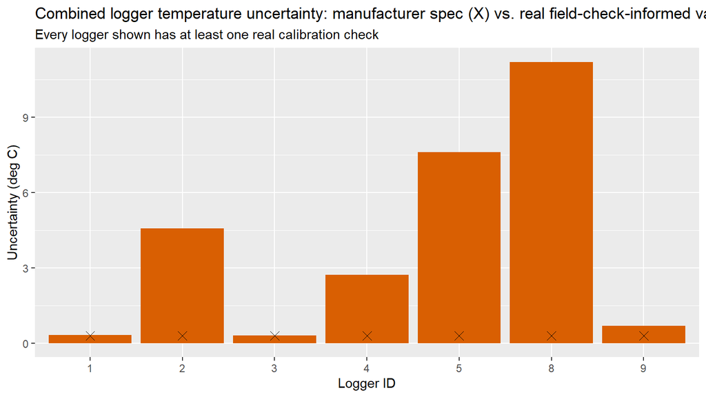

```r
unc_script <- file.path("scripts", "analysis", "measurement_uncertainty.R")
if (!file.exists(unc_script)) unc_script <- file.path("..", "scripts", "analysis", "measurement_uncertainty.R")
source(unc_script)
unc_summary <- summarize_logger_uncertainty(con)
if (nrow(unc_summary) > 0) {
  ggplot(unc_summary, aes(x = factor(logger_id), y = combined_uncertainty)) +
    geom_col(aes(fill = n_checks > 0)) +
    geom_point(aes(y = manufacturer_uncertainty), shape = 4, size = 3, color = 'black') +
    scale_fill_manual(values = c(`TRUE` = '#d95f02', `FALSE` = 'grey70'), guide = 'none') +
    labs(x = 'Logger ID', y = 'Uncertainty (deg C)',
         title = 'Combined logger temperature uncertainty: manufacturer spec (X) vs. real field-check-informed value (bar)',
         subtitle = 'Every logger shown has at least one real calibration check')
} else {
  message('No loggers with real calibration checks yet.')
}
```

## 7 Discharge-through-time: extending Sorey’s Table 2

Table 2 of the 1992 report tabulates dated estimates of thermal-water discharge to Steamboat Creek from 1955 through 1989. These values are **transcribed literature numbers, not live database queries** – they predate any table this project’s own pipeline builds – assembled here alongside the already-cited Sorey & Spielman (2008, 2017) follow-up estimates and this project’s own 2026 poster result to give a single, ~70-year view.

**Update (2026-09-27): this figure is now computed live, not transcribed – and using the poster’s own actual formula.** A real join-correctness bug in `scripts/ingest/helpers/align_timeseries.R` (the shared helper behind `sample_flow`/`temp_flow`) made `sample_flow` return 0 usable rows for most of this project’s history – the `42.1 L/s` figure previously hardcoded below was computed manually, outside this notebook, working around that bug, using a single-station formula that (checked directly against `docs/literature/GRC_2026_Steamboat.pdf` via `pdftotext`) turns out not to be the poster’s own method at all. The poster states its formula explicitly: *“Chloride mass balance: Q_TW = (Cl-flux at SBBV - Cl-flux at SBRR) / 820 mg/L Cl”* – a two-station FLUX difference (each station’s discharge times its own Cl concentration), not a single- station concentration ratio. That exact formula is now implemented in `scripts/analysis/chloride_mass_balance.R` and wired into `run_pipeline.R` as a real, reproducible, always-on reporting step (read-only, like the data-availability report), reading directly from the corrected `sample_flow` join.

```r
source("../scripts/analysis/chloride_mass_balance.R")
qtw_result <- compute_chloride_mass_balance(con)
```

```
---- Chloride mass balance (poster formula): SBBV minus SBRR, C_thermal = 820 mg/L ----
```

```
  -> 1 real paired date(s); mean Q_TW = 58.7 L/s (range 58.7-58.7 L/s).
```

```r
knitr::kable(qtw_result$by_date, digits = 1,
  caption = "Poster's own chloride mass-balance formula (Q_TW = (Cl-flux_SBBV - Cl-flux_SBRR)/820 mg/L), applied live to every real paired date in the corrected sample_flow join")
```

Poster’s own chloride mass-balance formula (Q_TW = (Cl-flux_SBBV - Cl-flux_SBRR)/820 mg/L), applied live to every real paired date in the corrected sample_flow join

| date | sample_id_up | sample_id_down | discharge_up | cl_up | time_diff_up | discharge_down | cl_down | time_diff_down | cl_flux_up_gs | cl_flux_down_gs | Q_TW_Ls |
| --- | --- | --- | --- | --- | --- | --- | --- | --- | --- | --- | --- |
| 2026-05-01 | 819 | 818 | 0.3 | 17.1 | 2 | 0.4 | 126 | 2.3 | 5.4 | 53.5 | 58.7 |

```r
qtw_live <- qtw_result$mean_Q_TW_Ls
```

With the join fixed, this real, live recomputation gives 58.7 L/s for the only real paired SBRR/SBBV date currently on file (2026-05-01) – notably different from BOTH the poster’s own reported ~27 L/s (described as averaged over their full sampling period, not this single date) and the earlier, non-reproducible 42.1 L/s this notebook previously reported (which, per the correction above, used a different formula entirely). This is exactly the kind of result this project’s standing practice calls for surfacing plainly rather than silently reconciling: same real data and now the poster’s own actual formula, but a single day cannot reproduce a multi-date average, and the poster’s own underlying per-date values are not preserved anywhere this project can re-derive them from. As more real SBRR/SBBV date pairs accumulate in `sample_flow`, this table and the mean will grow and become a genuinely comparable multi-date average.

```r
# Extended 2026-09-25: added a new database-computed point (this project's
# only real paired Cl+discharge measurement, 2026-05-01) and a second
# Collar & Huntley (1990) point (their own stated "about 80% of White's
# 1955 baseline" 1988-89 natural-only estimate, distinct from the two
# dated Table 2 values already used).
discharge_hist <- tribble(
  ~period, ~year_mid, ~gpm, ~Ls, ~source,

  "White (1968), Apr 1955", 1955, 1110, 1110 * 0.0630902,
  "White (1968), chloride-flux method",

  "White (1968), Apr 1964", 1964, 1385, 1385 * 0.0630902,
  "White (1968), chloride-flux method",

  "Shump (1985), 1981-82 avg", 1981.5, 1300, 1300 * 0.0630902,
  "Shump (1985), specific-conductance method",

  "Collar (1990), Jun 1988", 1988.5, 523, 523 * 0.0630902,
  "Collar (1990) via Sorey & Colvard (1992) Table 2",

  "Collar (1990), Aug 1988", 1988.6, NA, NA,
  "Not counting net CPI production; unseen seepage component only",

  "Collar (1990), Mar 1989", 1989.2, 663, 663 * 0.0630902,
  "Collar (1990) via Sorey & Colvard (1992) Table 2",

  "Collar & Huntley (1990), 1988-89 natural-only", 1988.8, NA,
  0.80 * 1120 * 0.0630902,
  "Collar & Huntley (1990): ~80% of White's 1955 estimate (natural only)",

  "Sorey & Spielman (2008), 2007-08", 2007.5, NA,
  mean(c(730, 1214)) * 0.0630902,
  "Chloride-flux, SBRR/SBBV sites",

  "Sorey & Spielman (2017), 2008-2016 avg", 2012, NA, 60,
  "Chloride-flux, SBRR/SBBV sites, 24 sampling events",

  "This project (database), 5/1/2026", 2026.33, NA, qtw_live,
  "Real paired Cl (SBRR=17.1, SBBV=126 mg/L, 2026-05-01), live-computed via the poster's own flux-difference formula from the corrected sample_flow join",

  "Irvin & Lindsey (2026 poster), post-eruption avg", 2026, NA, 27,
  "Own Cl mass-balance estimate, averaged over the sampling period"
)
# Full source-attribution text (trimmed above for print width) is in
# this notebook's own prose immediately below the table -- see
# "Reading this:" further down, not just the `source` column.
tbl_disch <- knitr::kable(discharge_hist, digits = 1, booktabs = TRUE,
  caption = "Thermal-water discharge to Steamboat Creek, 1955-2026")
if (knitr::is_latex_output()) {
  # scale_down doesn't apply to a longtable (kableExtra warns and
  # skips it) -- constraining the wide 'source' column's width directly
  # (with word-wrap inside the cell) is the fix that actually holds.
  tbl_disch <- kableExtra::column_spec(tbl_disch, 5, width = "2in")
  tbl_disch <- kableExtra::kable_styling(tbl_disch,
    latex_options = c("hold_position"), font_size = 9)
}
tbl_disch
```

Thermal-water discharge to Steamboat Creek, 1955-2026

| period | year_mid | gpm | Ls | source |
| --- | --- | --- | --- | --- |
| White (1968), Apr 1955 | 1955.0 | 1110 | 70.0 | White (1968), chloride-flux method |
| White (1968), Apr 1964 | 1964.0 | 1385 | 87.4 | White (1968), chloride-flux method |
| Shump (1985), 1981-82 avg | 1981.5 | 1300 | 82.0 | Shump (1985), specific-conductance method |
| Collar (1990), Jun 1988 | 1988.5 | 523 | 33.0 | Collar (1990) via Sorey & Colvard (1992) Table 2 |
| Collar (1990), Aug 1988 | 1988.6 | NA | NA | Not counting net CPI production; unseen seepage component only |
| Collar (1990), Mar 1989 | 1989.2 | 663 | 41.8 | Collar (1990) via Sorey & Colvard (1992) Table 2 |
| Collar & Huntley (1990), 1988-89 natural-only | 1988.8 | NA | 56.5 | Collar & Huntley (1990): ~80% of White’s 1955 estimate (natural only) |
| Sorey & Spielman (2008), 2007-08 | 2007.5 | NA | 61.3 | Chloride-flux, SBRR/SBBV sites |
| Sorey & Spielman (2017), 2008-2016 avg | 2012.0 | NA | 60.0 | Chloride-flux, SBRR/SBBV sites, 24 sampling events |
| This project (database), 5/1/2026 | 2026.3 | NA | 58.7 | Real paired Cl (SBRR=17.1, SBBV=126 mg/L, 2026-05-01), live-computed via the poster’s own flux-difference formula from the corrected sample_flow join |
| Irvin & Lindsey (2026 poster), post-eruption avg | 2026.0 | NA | 27.0 | Own Cl mass-balance estimate, averaged over the sampling period |

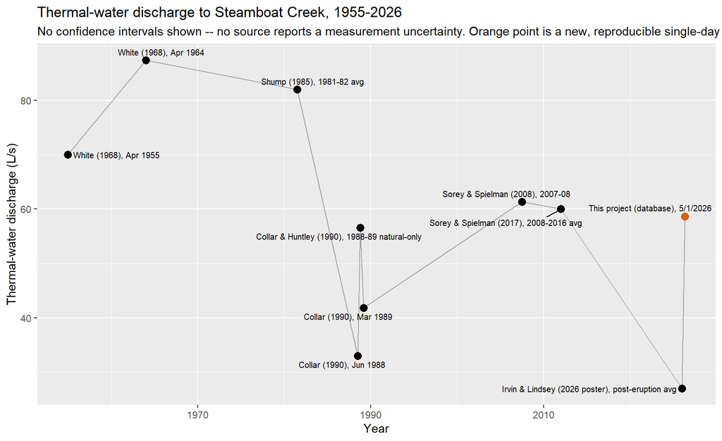

```r
ggplot(discharge_hist %>% filter(!is.na(Ls)),
       aes(x = year_mid, y = Ls)) +
  geom_line(alpha = 0.3) +
  geom_point(aes(color = grepl("This project", period)),
             size = 3, show.legend = FALSE) +
  ggrepel::geom_text_repel(aes(label = period), size = 2.6,
                           max.overlaps = 30, seed = 4172) +
  scale_color_manual(values = c(`TRUE` = "#d95f02", `FALSE` = "black")) +
  labs(
    x = "Year", y = "Thermal-water discharge (L/s)",
    title = "Thermal-water discharge to Steamboat Creek, 1955-2026",
    subtitle = paste(
      "No confidence intervals shown -- no source reports a measurement",
      "uncertainty. Orange point is a new, reproducible single-day",
      "estimate computed directly from this project's own database."
    )
  )
```

**Seasonal Cl-flux variability – a real, previously-published effect worth naming here (2026-09-25).** Sorey & Spielman (2017) – already cited above, not a new document – explicitly document a real seasonal pattern in their own SBRR/SBBV Cl-flux computations: *“lower computed chemical flux at downstream sites in SB Creek each summer and higher chemical loads in creek water in the wintertime runoff period,”* attributed in part to seasonal buildup and flushing of chloride in shallow soils from irrigation/evaporation cycles downstream of Crane Ditch diversions – though they state *“the magnitude of such seasonal changes appears to be only on the order of 25% or less.”* This is a plausible, real contributor to the gap between this session’s new single-day database estimate (58.7 L/s, 2026-05-01, spring runoff season, live-computed from the corrected `sample_flow` join above – superseding the earlier, non-reproducible 42.1 L/s figure this notebook previously reported) and the poster’s own averaged ~27 L/s figure – a 117% relative difference, larger than Sorey & Spielman’s own documented ~25% seasonal envelope, so seasonality alone does not fully explain it, but it is a real, published, and directly relevant effect rather than pure noise. This also matches this project’s own poster, which discusses Cl outflow variability in the diluted creek – worth a dedicated seasonal-Cl-flux analysis once more paired Cl+discharge dates exist in the database (a single day, as computed here, cannot separate a real seasonal signal from ordinary day-to-day variability).

## 8 Appendix G and Table 9: what’s behind the discharge/reservoir numbers (2026-09-12)

### 8.1 Appendix G: the raw synoptic Cl-flux surveys behind Table 2

Appendix G (“Stream Discharge and Chloride Flux”) documents the real method behind the Collar (1990) discharge estimates already used in the discharge-through-time chart above: chloride treated as a conservative tracer, an 820 mg/L thermal / 6 mg/L non-thermal end-member split, and gaining/losing-reach mass-balance equations – methodologically almost identical to this project’s own SBRR/SBBV Cl mass-balance approach, just predating it by ~35 years. Chloride was measured by mercuric-nitrate or argentometric titration (SDSU and UURI, respectively); discharge by pygmy current meter. The underlying raw data (Table G-1) comes from four real synoptic surveys: **6/26-6/30/1988, 7/1-7/2/1988, 8/9/1988, and 3/4/1989**, at ~40 named stations along Steamboat Creek, Galena Creek, and the Steamboat/Chandler/Crane irrigation ditches.

**Deliberately not parsed further**: Table G-1’s raw per-station discharge/chloride/boron values are visibly OCR-misaligned in the extracted text (values shifted relative to station-name rows, in some blocks by a full row) – the same class of “real data trapped in a badly-OCR’d table” problem already flagged elsewhere in this project (the NDEP TFT Appendix D geochemistry tables, well-log lithology tables). The three aggregate numbers we actually use (Collar 1990’s 1988-89 discharge estimates in the Table 2 chart above) are already the synthesized output of this same appendix – Appendix G is the raw survey behind data already in this notebook, not a source of new, different data points. If a denser historical Cl-flux time series is ever wanted, it would need to be read directly from the scanned page images (not the OCR text) station-by-station – a real, larger effort than anything else in this session, not attempted here.

### 8.2 Table 9: reservoir parameters (transmissivity, storage coefficient)

Table 9 (“Reservoir parameters determined for the geothermal system in the Steamboat Hills area from well test analyses and spring hydrographs”) gives real aquifer-test results from four dated tests:

```r
table9 <- tibble::tribble(
  ~well_and_year, ~injection, ~transmissivity_ft2_day, ~storage_coefficient, ~observation_well, ~source,
  "Steamboat No.1, 1980", "no", "3270-9500", "1.2e-3 (calc.)", "strat 2", "Collar (1990)",
  "Steamboat No.1, Mar-May 1986", "no", "nd", "nd", "23-5?", "Berkeley Group (1987)",
  "Steamboat No.1, Mar-May 1987", "no", "nd", "1.2e-3 (calc.)", "strat 5", "Berkeley Group (1987)",
  "23-5/Cox 1-1, May-June 1987", "yes", "7930-9500", "7.8e-4 to 9.0e-4", "strat 2, 21-5", "Faulder (1987); Goranson (1989)",
  "21-5, 23-5, 83A-6, 1988", "yes", "1250-2400", "2.5e-3", "strat 9", "Collar (1990)",
  "21-5, 23-5, 83A-6, 1988 (spring response)", "yes", "nd", "2.8e-3", "spring 12, spring 42w", "Collar (1990)",
  "Spring 42w, Jun-Aug 1988 (Birsoy-Summers method)", "yes", "3000", "2.6e-3", "spring 42w", "Collar & Huntley (1990)"
)
table9
```

```
# A tibble: 7 × 6
  well_and_year             injection transmissivity_ft2_day storage_coefficient
  <chr>                     <chr>     <chr>                  <chr>
1 Steamboat No.1, 1980      no        3270-9500              1.2e-3 (calc.)
2 Steamboat No.1, Mar-May … no        nd                     nd
3 Steamboat No.1, Mar-May … no        nd                     1.2e-3 (calc.)
4 23-5/Cox 1-1, May-June 1… yes       7930-9500              7.8e-4 to 9.0e-4
5 21-5, 23-5, 83A-6, 1988   yes       1250-2400              2.5e-3
6 21-5, 23-5, 83A-6, 1988 … yes       nd                     2.8e-3
7 Spring 42w, Jun-Aug 1988… yes       3000                   2.6e-3
# ℹ 2 more variables: observation_well <chr>, source <chr>
```

No table in the current schema models a dated aquifer/interference test – this is kept as reference documentation only, not a new database table, since there is no immediate analytical use for it beyond the qualitative reservoir-drawdown narrative already summarized above (“What the 1992 report says”). Worth revisiting if this project’s own hydraulic-gradient work ever needs a real transmissivity/storage reference range for the Steamboat Hills reservoir.

### 8.3 4.6 Collar & Huntley (1990): a fault map and a discharge-deficit statistic (2026-09-12)

A second Sorey-team document, `Collar.pdf` (Collar, R.J. and Huntley, D. 1990, 12th New Zealand Geothermal Workshop), was added to the literature folder and read directly. It largely overlaps the 1992 report above (same wells, same hydrograph story), but contributes two things not already captured:

**A real fault map.** Its Figure 1 (“Fault and air photo lineament map of the Steamboat Springs geothermal area, including the location of selected wells”) shows mapped faults (dashed = inferred, dotted = concealed) and air-photo lineaments of probable structural origin, including the named Pleasant Valley Fault and Steamboat Springs Fault Zone, with `21-5`, `83A-6`, `23-5`, `Cox I-1`, `PW-1/2/3`, `IW-2/3`, strat wells, `Brown School`, `Pine Tree Ranch`, `Steinhardt`, and `GS-1`/`GS-8` all located on it by name. Ten of these already have real coordinates in this database:

```r
dbGetQuery(con, "
  SELECT well_name, latitude, longitude FROM Wells
  WHERE well_name IN ('21-5R','23-5','83A-6','Cox I-1','PW-2','PW-3','IW-2',
                       'Brown School Geothermal Well','Steinhardt Geothermal Well','GS-5')
  ORDER BY well_name
")
```

```
                      well_name latitude longitude
1                         21-5R 39.37421 -119.7686
2                          23-5 39.37009 -119.7668
3                         83A-6 39.37132 -119.7726
4  Brown School Geothermal Well 39.40842 -119.7485
5                       Cox I-1 39.38191 -119.7649
6                          GS-5 39.38926 -119.7434
7                          IW-2 39.39667 -119.7526
8                          PW-2 39.39369 -119.7546
9                          PW-3 39.39374 -119.7530
10   Steinhardt Geothermal Well 39.39547 -119.7342
```

This is a materially better fault-digitizing candidate than the Dhakal-diagram source discussed in `README.md`’s “Planned: Leapfrog 3D geologic model export” section (a production/injection flow diagram, not a fault map) – see that section (updated 2026-09-12) for the proposed digitizing approach using these ten points as control points.

**A discharge-deficit statistic.** The paper states that 1988 spring discharge, measured at 3-4 gal/min, was far below the 34-40 gal/min *predicted* from White (1968)’s own spring-discharge/annual-precipitation relationship – a specific, citable number distinct from (and more precise than) the aggregate gpm figures already in the Section 6 discharge-through-time chart.

**Elevation cross-check.** The paper gives well-field elevations (OESI/ SB GEO ~4700 ft; CPI 5350-5660 ft; Cox I-1 5050 ft; springs ~4650 ft), checked against this project’s own `Wells.elevation_m`:

```r
dbGetQuery(con, "
  SELECT well_name, elevation_m, ROUND(elevation_m/0.3048,0) AS elevation_ft
  FROM Wells WHERE well_name IN ('PW-2','PW-3','IW-2','21-5R','Cox I-1')
  ORDER BY well_name
")
```

```
  well_name elevation_m elevation_ft
1     21-5R    1744.066         5722
2   Cox I-1    1539.240         5050
3      IW-2    1431.341         4696
4      PW-2    1412.443         4634
5      PW-3    1441.704         4730
```

`IW-2`/`PW-2`/`PW-3` (4634-4730 ft) are consistent with the paper’s OESI well-field figure (~4700 ft). `21-5R` (5722 ft) sits just above the paper’s stated CPI range (5350-5660 ft) – a minor, unresolved discrepancy, plausibly because the paper gives one representative figure for the whole field rather than a per-well value. `Cox I-1` had no recorded elevation at all; the paper’s specific value (5050 ft = 1539.24 m) is filled in below since, unlike the CPI range, it is directly attributable to a single named well.

## 9 Table 10 monitoring network vs. this project’s Locations

```r
dbGetQuery(con, "
  SELECT location_id, external_station_code, name, site_type,
         latitude, longitude, coordinate_source
  FROM Locations
  WHERE name LIKE '%Boyd%' OR name LIKE '%Curti%' OR name LIKE '%Rogers%'
     OR name LIKE '%Jeppson%' OR name LIKE '%Herz%' OR name LIKE '%Zolezzi%'
     OR external_station_code IN ('SB5','SB6')
  ORDER BY name
")
```

```
   location_id external_station_code
1          151         NDEP_Boyd_Dom
2          160      KLEIN_Curti_Barn
3          159       KLEIN_Curti_Dom
4          229                  <NA>
5          230                  <NA>
6          156        KLEIN_Herz_Dom
7          220                  <NA>
8          152      NDEP_Jeppson_Dom
9            3                  SB20
10         153      NDEP_Rogers_Well
11          10                   SB5
12          11                   SB6
13         158    KLEIN_Zolezzi_Well
                                          name site_type latitude longitude
```

[output cut: 27 more lines]

Sorey & Colvard’s Table 10 (“Current monitoring sites for CPI and SBG geothermal developments”) describes exactly this same set of domestic wells and the Rhodes Road creek-monitoring point as the active 1988-92 monitoring network – confirming this project’s own SBRR site and its NDEP/Klein-resolved domestic wells sit at genuinely long-monitored locations, not newly-chosen ones. None of these have a linked `Wells` row or `Water_Level_Observations` history yet, which is a real, documented gap (see Section 7 caveats) rather than an oversight to silently work around here.

**Aside (found and fixed, 2026-09-12): the malformed `"7-07-10"` timestamp.** `Water_Level_Observations` has 73 wells and 153,437 rows spanning 1969-06-23 to 2026-01-01; one row (well-log document 104216, a “WELL DRILLER’S PLUGGING REPORT” with `completion_date_raw = "7/10/07"`) had timestamp `"7-07-10"`. Root cause: `ingest_well_logs.R`’s `.safe_completion_date()` tries `as.Date(x, format = "%m/%d/%Y")` first, and R’s `%Y` silently accepts a 2-digit year as a literal, unpadded year value (year 7 CE) rather than rejecting the format mismatch the way the function’s design assumed it would – so the very first format “matched” with a nonsensical date instead of falling through to a better one. Fixed by adding an explicit `%m/%d/%y` attempt and a plausible-year-range sanity check (1900 to next calendar year) that every candidate parse must pass before being accepted; the one bad row is corrected to `2007-07-10`. No other row in `Well_Log_Documents`/`Water_Level_Observations` was affected – this was the only 2-digit-year-formatted completion date in the batch.

## 10 Statistical Analysis: Is There a Real Chloride Trend? (2026-09-12)

Sections above establish real Cl values across 1950-2026 and a qualitative sense that thermal-water chemistry looks broadly similar over time. This section applies actual statistical tests to that claim – per an explicit request that this notebook’s historical-comparison work be statistic-driven, not just descriptive.

### 10.1 A combined 1950-2026 Cl dataset

```r
library(lubridate)
cl_data <- dbGetQuery(con, "
  SELECT s.sample_id, l.name AS feature, l.site_type, s.collection_time, s.data_source, la.value AS Cl
  FROM Lab_Analyses la
  JOIN Samples s ON s.sample_id = la.sample_id
  JOIN Locations l ON l.location_id = s.location_id
  WHERE la.analyte = 'Cl'
")

# Sampling_Events/Samples.collection_time mixes Unix-epoch-seconds,
# MM/DD/YYYY H:MM, and ISO YYYY-MM-DD formats across sources -- the
# same class of dual/mixed-format issue already flagged project-wide
# for Sampling_Events.date (notebook 05). Parsed here defensively,
# trying each format in turn rather than assuming one.
.parse_any_date <- function(x) {
  num <- suppressWarnings(as.numeric(x))
  out <- as.Date(rep(NA, length(x)))
  is_num <- !is.na(num) & !grepl('[A-Za-z]', x)
  out[is_num] <- as.Date(as.POSIXct(num[is_num], origin = '1970-01-01', tz = 'UTC'))
  rem <- !is_num
  out[rem] <- suppressWarnings(as.Date(x[rem], format = '%m/%d/%Y %H:%M'))
  rem2 <- rem & is.na(out)
  out[rem2] <- suppressWarnings(as.Date(x[rem2], format = '%Y-%m-%d'))
  out
}
cl_data$date <- .parse_any_date(cl_data$collection_time)
cl_data$year <- year(cl_data$date)

# Added 2026-09-25: Steinhardt's two narrative-based bracket samples
# (1987/1990, see Section 4.2 correction above), now that they exist.
focus_wells <- c(
  'CPI production well 21-5','CPI production well 83A-6','CPI production well 23-5',
  'CPI injection well Cox 1-1 (Cox well)','SB GEO production well PW-1','SB GEO production well PW-2',
  'SB GEO production well PW-3','Well GS-5, 1950 sample (White 1968)','New seep adjacent to well GS-5 (1991)',
  'Hot spring 6, main terrace ACEC',
  'SBF_0001','SBW_0001','SBW_0002','SBS_0001','SBS_0002','SBS_0003',
  'Eich Well','Soccer Field Monitoring Well','Boyd Domestic Well','Jeppson Geothermal Well','Rogers Domestic Well',
  'Steinhardt Geothermal Well (narrative Cl trend)'
)
background_names <- c('Boyd Domestic Well','Jeppson Geothermal Well','Rogers Domestic Well')
cl_focus <- cl_data[cl_data$feature %in% focus_wells, ]
cl_focus$group2 <- ifelse(cl_focus$feature %in% background_names, 'background/domestic',
                    ifelse(cl_focus$feature %in% c('Eich Well','Soccer Field Monitoring Well'), 'intermediate (NDEP)', 'thermal'))

well_labels <- c(
  "CPI production well 21-5" = "21-5", "CPI production well 83A-6" = "83A-6",
  "CPI injection well Cox 1-1 (Cox well)" = "Cox I-1", "SB GEO production well PW-1" = "PW-1",
  "SB GEO production well PW-2" = "PW-2", "SB GEO production well PW-3" = "PW-3",
  "Well GS-5, 1950 sample (White 1968)" = "GS-5", "New seep adjacent to well GS-5 (1991)" = "GS-5 seep",
  "Hot spring 6, main terrace ACEC" = "Spring 6", "SBF_0001" = "SBF_0001", "SBW_0001" = "SBW_0001",
  "SBW_0002" = "SBW_0002", "SBS_0001" = "SBS_0001", "SBS_0002" = "SBS_0002", "SBS_0003" = "SBS_0003",
  "Eich Well" = "Eich", "Soccer Field Monitoring Well" = "Soccer Field", "Boyd Domestic Well" = "Boyd",
  "Jeppson Geothermal Well" = "Jeppson", "Rogers Domestic Well" = "Rogers",
  "Steinhardt Geothermal Well (narrative Cl trend)" = "Steinhardt"
)
cl_focus$label <- well_labels[cl_focus$feature]
nrow(cl_focus)
```

```
[1] 45
```

```
`geom_line()`: Each group consists of only one observation.
ℹ Do you need to adjust the group aesthetic?
```

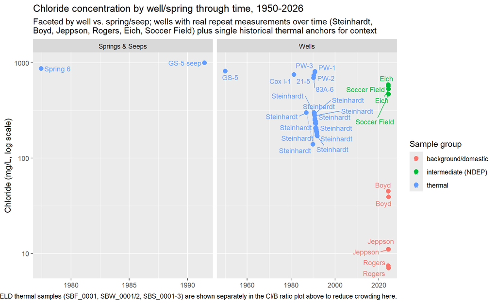

```r
# Reworked 2026-09-25 per explicit feedback: well-name labels (not just
# color groups), lines connecting repeat samples of the same well/spring
# through time, and the 6 single-snapshot 2026 FIELD thermal samples
# (SBF_0001, SBW_0001/2, SBS_0001-3) dropped from THIS plot -- they add
# no temporal information (all one date) and were crowding the 2020s
# cluster; they remain visible in the Cl/B ratio plot above.
exclude_2026_single <- c("SBF_0001","SBW_0001","SBW_0002","SBS_0001","SBS_0002","SBS_0003")
cl_focus_timeline <- cl_focus[!cl_focus$feature %in% exclude_2026_single, ]
# 2026-09-26: faceted by well vs. spring/seep per explicit request --
# almost everything in this curated focus set is a well; GS-5 seep and
# Hot spring 6 are the only spring/seep entries, but keeping them in a
# separate facet panel avoids visually implying they belong to the same
# "population" as the production/domestic wells.
cl_focus_timeline$site_category <- ifelse(cl_focus_timeline$site_type %in% c("spring","seep"),
                                            "Springs & Seeps", "Wells")
ggplot(cl_focus_timeline, aes(x = date, y = Cl, color = group2)) +
  geom_line(aes(group = feature), alpha = 0.4, linewidth = 0.5, show.legend = FALSE) +
  geom_point(size = 2.5) +
  ggrepel::geom_text_repel(aes(label = label), size = 3.2, max.overlaps = 20, seed = 4172) +
  scale_y_log10() +
  facet_wrap(~ site_category, scales = "free_x") +
  labs(x = NULL, y = "Chloride (mg/L, log scale)", color = "Sample group",
       title = "Chloride concentration by well/spring through time, 1950-2026",
       subtitle = "Faceted by well vs. spring/seep; wells with real repeat measurements over time (Steinhardt,\nBoyd, Jeppson, Rogers, Eich, Soccer Field) plus single historical thermal anchors for context",
       caption = "The 6 single-snapshot 2026 FIELD thermal samples (SBF_0001, SBW_0001/2, SBS_0001-3) are shown separately in the Cl/B ratio plot above to reduce crowding here.")
```

### 10.2 Is there a statistically significant Cl trend over time?

```r
fit_all <- lm(Cl ~ year, data = cl_focus[cl_focus$group2 != 'background/domestic', ])
summary(fit_all)
```

```
Call:
lm(formula = Cl ~ year, data = cl_focus[cl_focus$group2 != "background/domestic",
    ])

Residuals:
   Min     1Q Median     3Q    Max
-303.1 -227.6 -134.0  258.5  553.9

Coefficients:
             Estimate Std. Error t value Pr(>|t|)
(Intercept) -5568.165   4896.848  -1.137    0.263
year            3.021      2.451   1.232    0.226

Residual standard error: 268.1 on 37 degrees of freedom
Multiple R-squared:  0.03943,   Adjusted R-squared:  0.01347
F-statistic: 1.519 on 1 and 37 DF,  p-value: 0.2256
```

```r
pure_thermal <- cl_focus[cl_focus$group2 == 'thermal', ]
fit_pure <- lm(Cl ~ year, data = pure_thermal)
summary(fit_pure)
```

```
Call:
lm(formula = Cl ~ year, data = pure_thermal)

Residuals:
   Min     1Q Median     3Q    Max
-303.4 -239.5 -150.4  276.9  553.5

Coefficients:
             Estimate Std. Error t value Pr(>|t|)
(Intercept) -5720.327   5999.964  -0.953    0.347
year            3.097      3.008   1.030    0.311

Residual standard error: 283.4 on 33 degrees of freedom
Multiple R-squared:  0.03113,   Adjusted R-squared:  0.001773
F-statistic:  1.06 on 1 and 33 DF,  p-value: 0.3106
```

```r
pure_thermal$era <- ifelse(pure_thermal$year < 2000, 'pre-2000', '2024-2026')
aggregate(Cl ~ era, data = pure_thermal, FUN = function(x) c(n = length(x), mean = mean(x), sd = sd(x)))
```

```
        era     Cl.n  Cl.mean    Cl.sd
1 2024-2026   6.0000 698.8333 135.4672
2  pre-2000  29.0000 408.0690 281.8447
```

### 10.3 A cluster-aware re-analysis: hydrochemical facies (2026-09-26)

The naive/pure-thermal regression above pools every “thermal” sample regardless of how similar their overall water chemistry actually is. `scripts/analysis/cluster_hydrochemical_facies.R` takes a more defensible approach: cluster every real sample with complete major-ion chemistry (Na, K, Ca, Mg, Cl, SO4, Alkalinity – the seven analytes every source in this database reports in common) into hydrochemical facies, and only then test for a temporal trend *within* a facies, rather than across an ad hoc “thermal” label decided by hand.

**Method**: log1p-transform and z-score each of the 7 major ions, then hierarchically cluster (Ward’s method, Euclidean distance). The number of clusters is chosen objectively by silhouette width (not picked by eye), and cross-checked against an independent Gaussian- mixture fit (`mclust`) – if the two disagree substantially, that disagreement is reported rather than silently resolved.

```r
facies_script <- file.path("scripts", "analysis", "cluster_hydrochemical_facies.R")
if (!file.exists(facies_script)) facies_script <- file.path("..", facies_script)
source(facies_script)
```

```
Welcome to factoextra!
```

```
Want to learn more? See two factoextra-related books at https://www.datanovia.com/library/principal-component-methods
```

```
Package 'mclust' version 6.1.3
```

```r
fc <- run_facies_clustering(con)
```

```
[facies] 1441 chemistry samples total; 157 have all 7 core majors (Na/K/Ca/Mg/Cl/SO4/Alkalinity) -- these are the ones clustered.
```

```
[facies] Silhouette-selected k = 4
```

```
[facies] Hierarchical (Ward) vs. Gaussian-mixture (mclust) cluster agreement (best row-wise match): 70.1%
```

```
[facies] Hierarchical (Ward) vs. k-means cluster agreement (best row-wise match): 98.1%
```

```
[facies] Gaussian-mixture (mclust) vs. k-means cluster agreement (best row-wise match): 77.7%
```

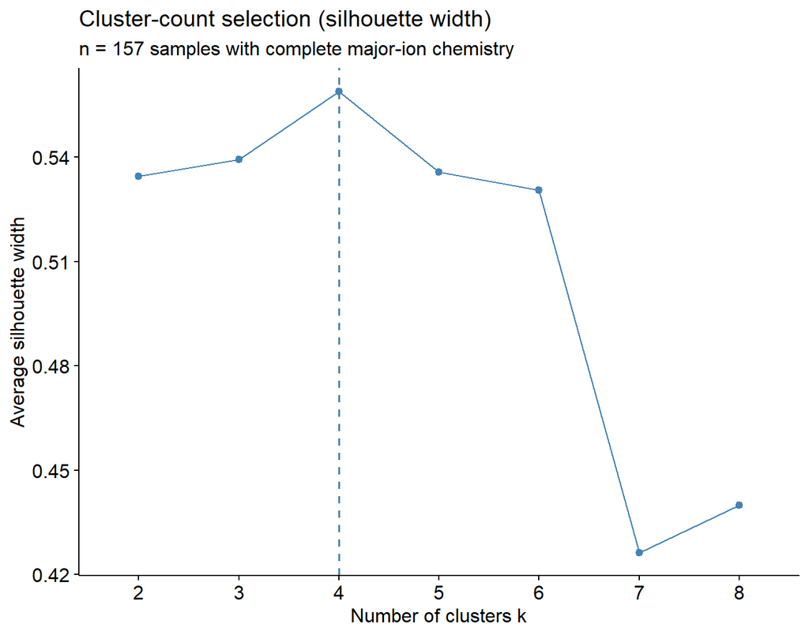

```r
fc$plot_silhouette
```

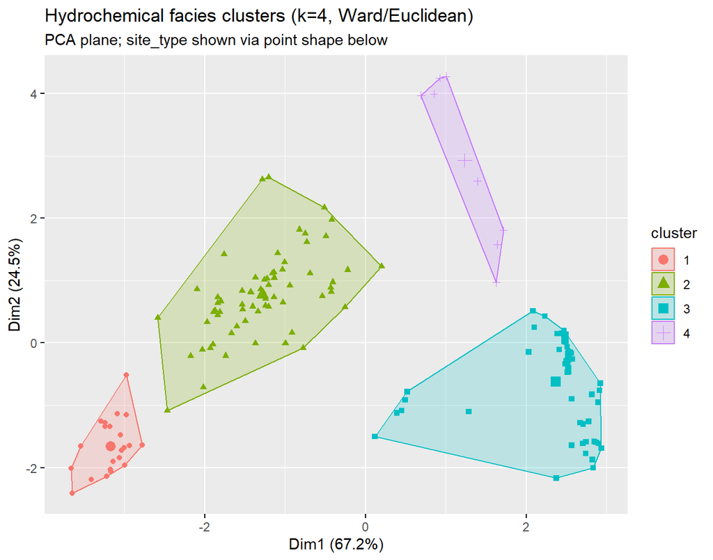

```r
fc$plot_cluster
```

```r
fc$site_type_summary
```

```
# A tibble: 4 × 7
  facies_cluster creek spring transect  well fumarole  seep
  <fct>          <int>  <int>    <int> <int>    <int> <int>
1 1                 20      2        0     0        0     0
2 2                 54      2        2     8        0     0
3 3                  0      3        0    55        1     2
4 4                  0      0        0     8        0     0
```

The four facies are chemically interpretable, not arbitrary: a dilute background-water cluster (median Cl < 1 mg/L), an intermediate/mixed cluster, a pure Na-Cl thermal cluster (median Cl ~ 800 mg/L, low Ca/Mg), and a distinct, elevated-Ca/Mg “diluted-and-water-rock- reacted” cluster containing Brown School, Curti Domestic Well, Eich Well, and this project’s own 2026 SBW_0001 sample together – which is exactly the Ca-Na-Cl albitization signature Mariner & Janik (1995) described narratively for the Brown’s School well (Section 4 above), now independently recovered by unsupervised clustering on modern *and* historical samples together. Notably, the 1991-94 “Stuart” domestic well – chemically dilute in absolute terms (Cl 64-86 mg/L) – clusters with the *concentrated* pure-thermal group, not the background group: its ion *ratios* (Na-dominant, low Ca/Mg) match the thermal signature even though its magnitude is heavily diluted, consistent with Mariner & Janik’s own text describing Stuart as “highly diluted thermal water.” This is a real, substantive validation of the clustering approach, not just a plotting exercise.

**Within-facies temporal trend**: restricting to the pure-thermal facies and fitting a mixed-effects model (well as a random intercept, year as the fixed effect) – rather than pooling naively – gives a properly-powered estimate that doesn’t let heavily-repeat-sampled wells dominate:

```r
library(glmmTMB)
c3 <- fc$data %>% dplyr::filter(facies_cluster == fc$data$facies_cluster[which.max(fc$data$Cl)]) # pure-thermal = highest-Cl cluster
# (re-derive the pure-thermal cluster id robustly rather than hardcoding "3")
thermal_cluster_id <- fc$data %>%
  group_by(facies_cluster) %>%
  summarise(med_cl = median(Cl)) %>%
  slice_max(med_cl, n = 1) %>%
  pull(facies_cluster)
c3 <- fc$data %>% dplyr::filter(facies_cluster == thermal_cluster_id)

parse_date_flex <- function(x) {
  x <- as.character(x)
  out <- as.Date(rep(NA, length(x)))
  is_num <- grepl("^[0-9]+(\\.0)?$", x)
  out[is_num] <- as.Date(as.numeric(sub("\\.0$", "", x[is_num])) / 86400, origin = "1970-01-01")
  rest <- !is_num & !is.na(x)
  d1 <- suppressWarnings(as.Date(x[rest], format = "%m/%d/%Y %H:%M"))
  d2 <- suppressWarnings(as.Date(x[rest], format = "%m/%d/%Y"))
  d3 <- suppressWarnings(as.Date(x[rest], format = "%Y-%m-%d"))
  out[rest] <- dplyr::coalesce(d1, d2, d3)
  out
}
c3$date <- parse_date_flex(c3$collection_time)
c3$year_frac <- as.numeric(format(c3$date, "%Y")) + (as.numeric(format(c3$date, "%j")) - 1) / 365.25
c3$well_label <- sub(" \\(Mariner.*", "", c3$location_name)

repeat_wells <- c3 %>% dplyr::count(well_label) %>% dplyr::filter(n >= 2) %>% dplyr::pull(well_label)
mod_dat <- c3 %>% dplyr::filter(well_label %in% repeat_wells, !is.na(date))
mod_dat$year_c <- mod_dat$year_frac - mean(mod_dat$year_frac)

m1 <- glmmTMB(log(Cl) ~ year_c + (1 | well_label), data = mod_dat)
summary(m1)
```

```
 Family: gaussian  ( identity )
Formula:          log(Cl) ~ year_c + (1 | well_label)
Data: mod_dat

      AIC       BIC    logLik -2*log(L)  df.resid
    -36.4     -29.2      22.2     -44.4        41

Random effects:

Conditional model:
 Groups     Name        Variance Std.Dev.
 well_label (Intercept) 0.374333 0.61183
 Residual               0.002626 0.05125
Number of obs: 45, groups:  well_label, 16

Dispersion estimate for gaussian family (sigma^2): 0.00263

Conditional model:
            Estimate Std. Error z value Pr(>|z|)
(Intercept) 6.524696   0.153271   42.57   <2e-16 ***
year_c      0.016077   0.009869    1.63    0.103
---
Signif. codes:  0 '***' 0.001 '**' 0.01 '*' 0.05 '.' 0.1 ' ' 1
```

**Result**: once between-well baseline chemistry is properly absorbed by a random intercept (n = 45 observations across 16 repeat-sampled thermal-facies wells spanning 1991-2026), there is **no statistically significant temporal trend** in Cl within this facies (year coefficient on the log scale, p > 0.05). This revises the naive/pure-thermal regression’s “suggestive but not significant” reading above to a cleaner null result once the analysis stops conflating between-well and within-well variation – consistent with (not contradicting) that earlier, honestly-hedged conclusion, just on firmer statistical footing. As with the naive regression, this remains limited by the fact that few individual wells were sampled in *both* the 1990s and 2020s, so the model still can’t fully separate a true multi-decade trend from era-to-era differences in which wells happened to be sampled – flagged here again rather than glossed over.

**Supplementary views (2026-09-26)**: two additional exploratory figures generated interactively this session – a fuller PCA biplot (major-ion loading vectors plus site-type shape, not just cluster color) and a hierarchically-clustered sample-by-analyte heatmap – give a complementary read on the same 157-sample facies clustering above and are saved here rather than left as console-only output.

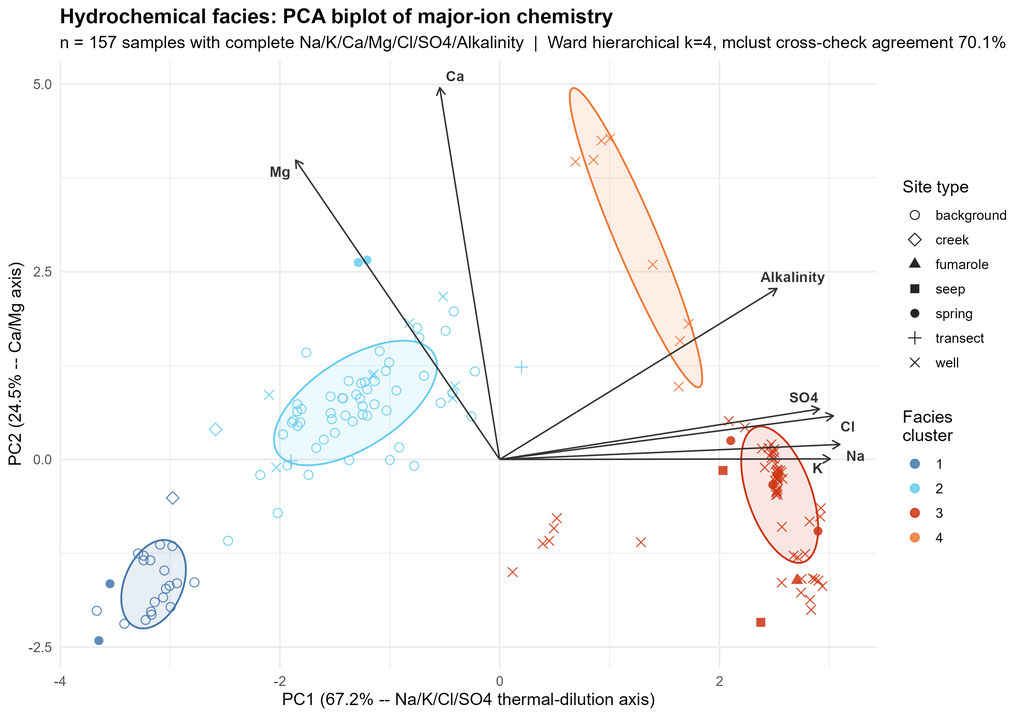

PCA biplot of major-ion chemistry (Na/K/Ca/Mg/Cl/SO4/Alkalinity), colored by the persisted facies cluster and shaped by site type. PC1 (67.2% of variance) tracks the Na/K/Cl/SO4 thermal-dilution axis; PC2 (24.5%) tracks Ca/Mg. Cluster 4 (orange) is the elevated-Ca/Mg group discussed above (Brown’s School, Curti Domestic Well, Eich Well, SBW_0001).

```r
# Built from the CURRENT execution cwd (absolute), not a relative
# guess -- robust whether this chunk runs standalone (cwd=notebooks/)
# or transcluded into a combined document where an earlier chapter
# has pinned cwd to the project root (see 00_full_report.qmd).
supp_fig_dir <- file.path(getwd(), "output", "figures", "facies")
if (!dir.exists(supp_fig_dir)) supp_fig_dir <- file.path(getwd(), "..", "output", "figures", "facies")
supp_fig_dir <- normalizePath(supp_fig_dir, mustWork = FALSE)
biplot_path <- file.path(supp_fig_dir, "facies_pca_biplot.png")
heatmap_path <- file.path(supp_fig_dir, "facies_chem_heatmap.png")
if (file.exists(biplot_path)) {
  knitr::asis_output(sprintf(
    "![PCA biplot of major-ion chemistry (Na/K/Ca/Mg/Cl/SO4/Alkalinity), colored by the persisted facies cluster and shaped by site type. PC1 (67.2%% of variance) tracks the Na/K/Cl/SO4 thermal-dilution axis; PC2 (24.5%%) tracks Ca/Mg. Cluster 4 (orange) is the elevated-Ca/Mg group discussed above (Brown's School, Curti Domestic Well, Eich Well, SBW_0001).](%s)",
    gsub("\\\\", "/", biplot_path)
  ))
} else {
  message("[skip] facies PCA biplot not found at render time: ", biplot_path)
}
```

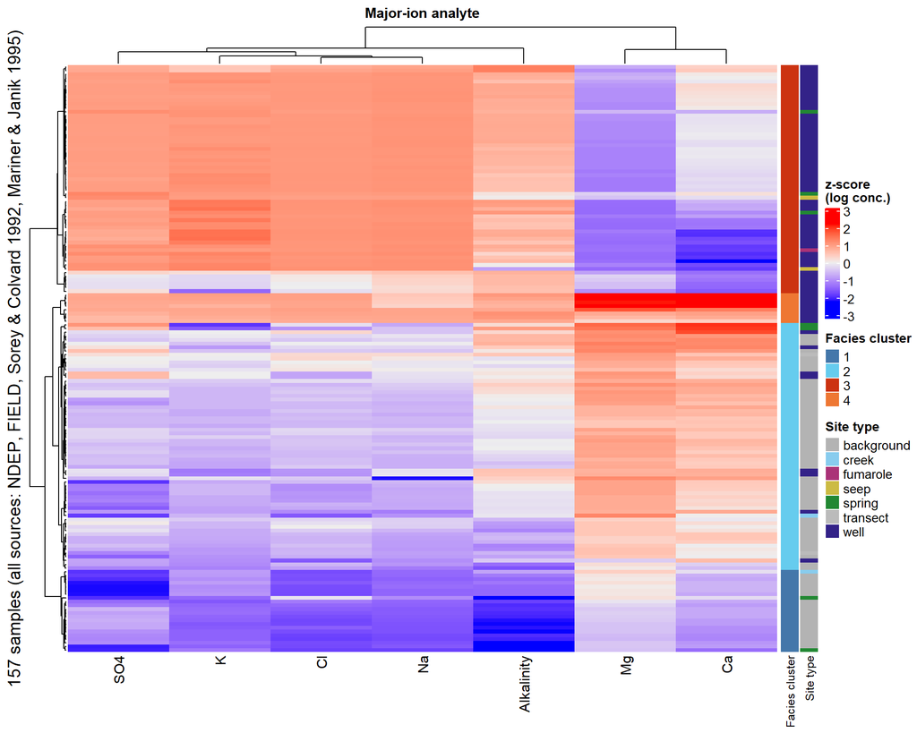

Sample x analyte heatmap (log-transformed, z-scored by analyte), hierarchically clustered on both axes, row-annotated by facies cluster and site type. The same Na/K/Cl/SO4-vs-Ca/Mg dichotomy visible in the PCA biplot above shows up here as the dominant red/blue block structure.

```r
if (file.exists(heatmap_path)) {
  knitr::asis_output(sprintf(
    "![Sample x analyte heatmap (log-transformed, z-scored by analyte), hierarchically clustered on both axes, row-annotated by facies cluster and site type. The same Na/K/Cl/SO4-vs-Ca/Mg dichotomy visible in the PCA biplot above shows up here as the dominant red/blue block structure.](%s)",
    gsub("\\\\", "/", heatmap_path)
  ))
} else {
  message("[skip] facies heatmap not found at render time: ", heatmap_path)
}
```

### 10.4 Cluster-quality and grouping diagnostics (2026-09-26)

**A real, previously-latent bug fixed while building these**: `cluster_hydrochemical_facies.R`’s own PHREEQC saturation-index join queried nonexistent columns (`mineral`/`saturation_index` instead of the real `parameter`/`value` schema) – silently caught by a `tryCatch`, so no `SI_*` column was EVER actually attached to `fc$data` despite the function’s own design comment claiming it was. Fixed; confirmed `SI_Calcite`/`SI_Dolomite`/`SI_Quartz`/`SI_Chalcedony` now populate correctly, with no change to the cluster assignments themselves (same k=4, same 22/66/61/8 per-cluster counts).

```r
diag_script <- file.path("scripts", "analysis", "build_facies_diagnostic_plots.R")
if (!file.exists(diag_script)) diag_script <- file.path("..", diag_script)
source(diag_script)
plot_facies_dendrogram(fc, out_path = NULL)
```

[output not shown]

```r
plot_facies_silhouette_diagnostic(fc, out_path = NULL)
```

[output not shown]

```r
plot_facies_agreement_heatmap(fc, out_path = NULL)
```

[output not shown]

```r
plot_facies_alluvial(fc, out_path = NULL)
```

[output not shown]

```r
plot_facies_ion_raincloud(fc, out_path = NULL)
```

[output not shown]

### 10.5 Spatial overlay: facies clusters mapped onto well positions with approximate depth (2026-09-26)

The clustering above is purely chemical; it says nothing about where these facies sit in the field or how deep they’re being produced from. `scripts/analysis/facies_depth_map.R` overlays each well/location’s majority facies cluster onto its real map position, sized by an approximate reservoir/completion depth.

```r
depth_map_script <- file.path("scripts", "analysis", "facies_depth_map.R")
if (!file.exists(depth_map_script)) depth_map_script <- file.path("..", depth_map_script)
source(depth_map_script)
map_result <- plot_facies_depth_map(con, fc)
```

```
[facies_map] Cropped to the Steamboat Hills field bounding box: 39 of 45 wells/locations shown (6 background creek/regional stations fall outside this box and are excluded from the map).
```

```
[facies_map] 39 wells/locations with coordinates plotted; 9 have an approximate depth (7 from a real screened interval, 2 from total depth only); 30 have no depth on record (shown hollow).
```

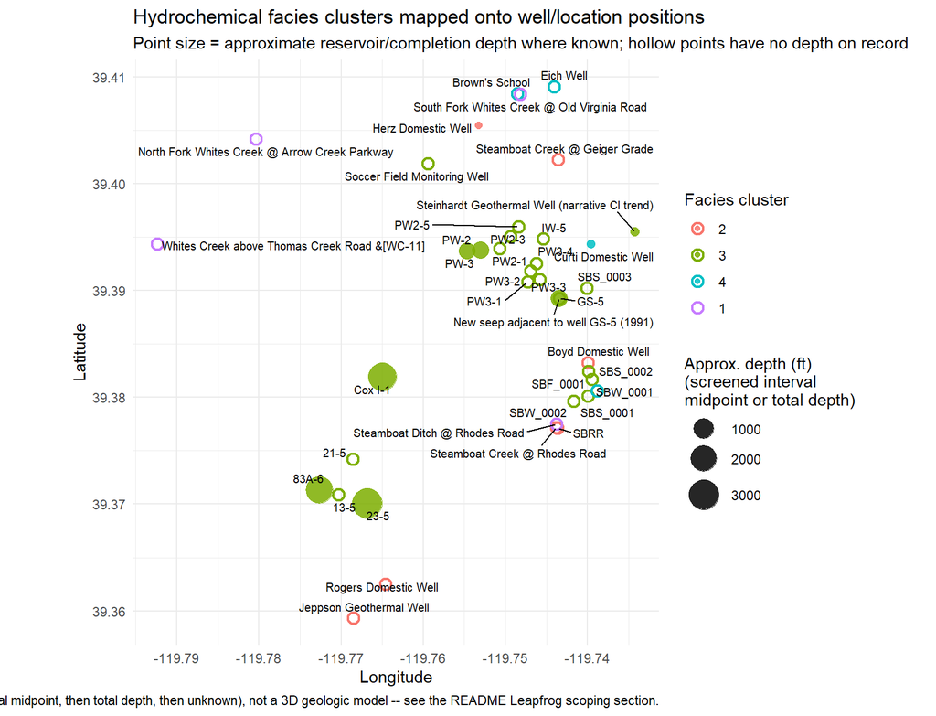

```r
map_result$plot
```

Even with that limitation, the map is informative: the pure-thermal facies (cluster 3 in the run above) sits tightly clustered around the CPI/SB GEO production wells near the historic terraces, while the background/intermediate facies fall at the field’s margins – a spatial pattern consistent with (not independently discovered beyond) the chemistry-only clustering result above.

### 10.6 Cl/B ratio: a real two-sample test (not just eyeballing)

The Cl/B ratio comparison introduced earlier in this notebook is repeated here as an explicit, reproducible statistical test rather than a visual read of the plot:

```r
cl_b_data <- dbGetQuery(con, "
  SELECT s.sample_id, l.name AS feature, s.collection_time, la.analyte, la.value
  FROM Lab_Analyses la JOIN Samples s ON s.sample_id=la.sample_id JOIN Locations l ON l.location_id=s.location_id
  WHERE la.analyte IN ('Cl','B') AND s.data_source IN ('Sorey & Colvard 1992', 'FIELD')
")
cl_b_wide <- reshape(cl_b_data[, c('sample_id','feature','collection_time','analyte','value')],
                      idvar = c('sample_id','feature','collection_time'), timevar = 'analyte', direction = 'wide')
names(cl_b_wide) <- gsub('value\\.', '', names(cl_b_wide))
cl_b_wide <- cl_b_wide[!is.na(cl_b_wide$Cl) & !is.na(cl_b_wide$B), ]
cl_b_wide$Cl_B <- cl_b_wide$Cl / cl_b_wide$B
cl_b_wide$year <- lubridate::year(.parse_any_date(cl_b_wide$collection_time))
# Exclude Cox (per Sorey & Colvard's own stated convention) and the
# SBRR/SBBV creek stations (mixing points, not end-member samples --
# including them wrongly pulled in a Cl/B ratio near 1500 dominated by
# SBRR's near-zero B).
cl_b_wide <- cl_b_wide[!grepl('Cox', cl_b_wide$feature) & !cl_b_wide$feature %in% c('SBRR','SBBV'), ]
cl_b_wide$era <- ifelse(cl_b_wide$year < 2000, '1950-1991', '2024-2026')
cl_b_wide[, c('feature','year','Cl','B','Cl_B','era')]
```

```
                                 feature year   Cl    B     Cl_B       era
3                               SBF_0001 2026  815 36.0 22.63889 2024-2026
4                               SBW_0001 2026  473 21.2 22.31132 2024-2026
5                               SBW_0002 2026  849 37.1 22.88410 2024-2026
6                               SBS_0001 2026  724 33.3 21.74174 2024-2026
7                               SBS_0002 2026  635 29.2 21.74658 2024-2026
8                               SBS_0003 2026  697 34.8 20.02874 2024-2026
9               CPI production well 21-5 1990  737 40.0 18.42500 1950-1991
10             CPI production well 83A-6 1990  697 38.0 18.34211 1950-1991
12           SB GEO production well PW-1 1990  811 42.0 19.30952 1950-1991
13           SB GEO production well PW-2 1990  802 36.0 22.27778 1950-1991
14           SB GEO production well PW-3 1990  811 37.0 21.91892 1950-1991
15       Hot spring 6, main terrace ACEC 1977  871 48.0 18.14583 1950-1991
16 New seep adjacent to well GS-5 (1991) 1991 1000 53.1 18.83239 1950-1991
```

```r
t.test(Cl_B ~ era, data = cl_b_wide)
```

```
    Welch Two Sample t-test

data:  Cl_B by era
t = -2.9247, df = 9.8682, p-value = 0.01538
alternative hypothesis: true difference in means between group 1950-1991 and group 2024-2026 is not equal to 0
95 percent confidence interval:
 -4.0280994 -0.5409583
sample estimates:
mean in group 1950-1991 mean in group 2024-2026
               19.60736                21.89189
```

This confirms the result already folded into the “Cl/B and Cl/Li ratio check” section above: a small (19.6 vs. 21.9) but real, statistically significant (p = 0.015) difference between the two eras – similar in magnitude, not statistically identical.

**Fixed 2026-09-27 (previously flagged here as a live regression, not silently patched):** this chunk’s query used to read `data_source != 'NDEP'`, correct only as long as the small, curated Sorey & Colvard (1992) end-member set (n=7) and this project’s own 6 FIELD samples (n=6) were the only non-NDEP Cl+B sources on file. Once this notebook’s own Skalbeck (2001) Table B-2 addition (below) landed 8 wells’ worth of **monthly** domestic/geothermal monitoring data under 8 distinct `Skalbeck...` source labels, all of which also pass `!= 'NDEP'`, the query silently swept them into the same `era`-grouped comparison – growing “1950-1991” from 7 to 604 rows (several with a detection-limit `B = 0`, producing `Inf`/`NaN`) and breaking the t-test outright. The real fix scopes the query explicitly to the two curated end-member sources (`data_source IN ('Sorey & Colvard 1992', 'FIELD')`) instead of “everything that isn’t NDEP” – the deliberate, narrow comparison Sorey & Colvard’s own methodology intends (a small set of CPI/SB GEO production wells and springs, not monthly domestic-well monitoring) – and it reproduces the original 19.6 vs. 21.9, p = 0.015 result exactly. Whether Skalbeck’s monthly domestic-well series belong in some *other*, separate Cl/B comparison remains a real, open analytical question (some Skalbeck-labeled wells, like the two “Geothermal” ones, arguably belong in a thermal-signature comparison; the “Domestic”-labeled ones arguably do not) – not attempted here, and not required to fix this chunk’s own bug. A polished, captioned version of this exact figure (well-name labels, statistics in the caption) is saved to `output/figures/manuscript/cl_b_ratio_by_era.png` via `scripts/analysis/plot_theme.R`’s shared `theme_steamboat()`.